# OCN 682 - Group A - OPIHI AI Data Sprint

Author

Wei Shen Lim, Fabi Zamora, Natalie Goeler-Slough, Ellie S Jones

Published

November 9, 2026

**This Quarto document contains all combined code from Group A to clean, organize, and plot data from Our Project In Hawaiʻi’s Intertidal (OPIHI).**

## Data Cleaning

### **Overview**

These are the scripts we used to anonymize all schools, teachers, and students’ names from the raw data files, before they were uploaded onto the public repository under `Data_Clean` folder to be used to create the final cleaned master sheet (`final_clean_master_sheet.csv`) for all raw data available from 2004-2026.

Data files which were omitted as a whole include:

- `Copy of OPIHI Field Study 2023 - ALL Group Data (P1_P2)`
- `Copy of OPIHI Field Study 2025 - ALL Group Data (P1_P2) - use this one!`
- `OPIHI Field Study 2026 - Waipuilani Data`
- `OPIHI Data - Reformated`
- `Playing around... Jo March 2022`
- `Sandy Beach Only`

Field Study data files from 2023, 2025, and 2026 were omitted because these are grouped/summary data, not raw data. The remaining 3 data files were attempts at making master sheets, so these only contain duplicate data.

Additionally, all individual tabs/sheets that are about transect point data, percent cover, and grouped/summary data were omitted. This means only metadata and raw quadrat point-intercept data were taken and used to build the final cleaned master sheet (`final_clean_master_sheet.csv`).

### **Part 1: Anonymizing Names**

Set working directory to your own file that has all the private raw data files with names.

#### **Load Libraries**

```r
library(tidyverse)
```

#### **Load Functions**

Function 1: Anonymize school names for data files from 2004 to 2020

```r
anonymize_school_data_batch <- function(input_files) {

  # Step 1: Scan ALL files combined to build a unified Master Lookup Sheet
  master_lookup <- input_files |>
    map(read_lines) |>                   #read every file in vector as raw character vector of lines
    flatten_chr() |>                     #merges the split lists of lines into one large, single vector of text strings
    keep(~ str_starts(.x, "School,")) |> #filters lines to keep only rows that begin with "School,"
    str_split(",") |>                    #breaks those comma-separated rows apart into individual cell strings
    flatten_chr() |>                     #flattens nested list of row items into a single flat character vector
    str_trim() |>                        #drops any accidental leading or trailing white spaces from each cell string
    keep(~ .x != "School" & .x != "") |> #drops empty text spaces and the original label "School"
    unique() |>                          #filters items down to keep only distinct school entries
    tibble(original_name = _) |>         #converts final vector into a tidyverse data frame under column "origianl_name"
    mutate(school_id = paste0("School_", row_number())) #creates sequential IDs based on row counts

  # Write out the single combined lookup sheet
  write_csv(master_lookup, "combined_school_lookup_2004_2020.csv")

  # Step 2: Loop through each file individually to anonymize its text columns
  walk(input_files, function(input_file) {

     # Dynamically generate clean names for the output data files
    base_name <- str_remove(input_file, "\\.[cC][sS][vV]$")    #trims the .csv/.CSV extension off filename string
    data_output <- paste0(base_name, "_anonymized_output.csv") #appends a standardized suffix to create output filename

    read_lines(input_file) |>
      tibble(text_line = _) |> #load raw file lines into a single-column tracking data frame
      rowwise() |>             #compute subsequent mutate changes line-by-line instead of as a block vector
      mutate(
        text_line = if (str_starts(text_line, "School,")) { #checks if row is the target metadata line
          elements <- str_split(text_line, ",")[[1]]        #splits the comma-separated string row into a clean, flat character vector

          anon_elements <- map_chr(elements, function(x) { #loops through every column cell inside this text row one by one
            clean_x <- str_trim(x)                         #temporarily cleans up the text cell to evaluate its contents accurately
            if (clean_x == "School" || clean_x == "") { #checks if the cell is part of the blank spacing or the row header label
              return(x)                                 #returns the exact original text string, no modification or substitution
            } else if (clean_x %in% master_lookup$original_name) {                    #checks if the cell value matches an entry in our master tracking key
              return(master_lookup$school_id[master_lookup$original_name == clean_x]) #swaps out original name for its matching ID
            } else {
              return(x)                                 #default fallback: returns original cell text if no conditions are matched
            }
          })

          paste(anon_elements, collapse = ",") #glues the individual anonymized column cells back into a unified CSV row string
        } else {
          text_line                            #conditional fallback: leaves all rows not starting with "School," completely unmodified
        }
      ) |>
      ungroup() |>             #dissolves the rowwise grouping structure to return the data frame to its normal state
      pull(text_line) |>       #extracts the text columns back out into a raw vector of layout text lines
      write_lines(data_output) #saves final structural text file to working directory
  })
}
```

Function 2: Anonymize student/teacher names for data files from 2024 to 2026.

```r
anonymize_data_entry_batch <- function(input_files) {

  # Step 1: Scan all files to extract unique "Data Entry By" names for the Master Lookup
  master_lookup <- input_files |>
    map_df(~ {                                          #maps across files and row-binds the resulting data frames together automatically
      read_csv(.x, skip = 1, show_col_types = FALSE) |> #skips row 1, captures actual column header strings on row 2
        select(`Data Entry By`)                         #keeps only "Data Entry By" column, discards all other
    }) |>
    drop_na(`Data Entry By`) |>                            #filters out missing cells or blank data entries from the table rows
    mutate(`Data Entry By` = str_trim(`Data Entry By`)) |> #strips off accidental leading or trailing white spaces from names
    filter(`Data Entry By` != "") |>                       #filters out any rows where the name is a blank text string ("")
    distinct() |>                                          #drops any duplicate names extracted across multiple days or files
    rename(original_name = `Data Entry By`) |>             #renames column to "original_name" to serve as a clean reference column
    mutate(coder_id = paste0("Coder_", row_number()))      #generates sequential IDs based on row numbers in this unique list

  # Save out the unified master lookup table
  write_csv(master_lookup, "combined_data_entry_lookup_2024_2026.csv")

  # Step 2: Loop back through each file, replace names, and write out cleanly
  walk(input_files, function(input_file) {
    base_name <- str_remove(input_file, "\\.[cC][sS][vV]$")    #trims the .csv/.CSV extension off filename string
    data_output <- paste0(base_name, "_anonymized_output.csv") #appends a standardized suffix to create output filename

    # Read the banner row separate to preserve it at the top of our output file
    banner_row <- read_lines(input_file, n_max = 1)

    # Read the main data matrix
    data_matrix <- read_csv(input_file, skip = 1, show_col_types = FALSE) |> #loads data grid from row 2 down
      mutate(`Data Entry By` = str_trim(`Data Entry By`)) |>                 #strips off accidental leading or trailing white spaces from names
      left_join(master_lookup, by = c("Data Entry By" = "original_name")) |> #merges master lookup key into this file by matching local names to "original_name"
      mutate(`Data Entry By` = coder_id) |>                                  #overwrites original names with anonymized IDs
      select(-coder_id)                                                      #removes the temporary helper "coder_id" column generated by the merge step

    # Write the banner row back manually, then append the anonymized dataset
    write_lines(banner_row, data_output)
    write_csv(data_matrix, data_output, append = TRUE, col_names = TRUE) #appends modified data table with its column headers directly underneath that first line/row
  })
}
```

Function 3: Anonymize team leaders and members’ names for metadata files from 2025 & 2026

```r
anonymize_team_batch <- function(input_files) {

  # Helper to isolate individual names from multi-person strings safely
  extract_individual_names <- function(text_vector) {
    text_vector |>
      str_split(",|\\band\\b") |>                                #splits strings by commas or the word "and"
      flatten_chr() |>                                           #condenses the list arrays down into a single flat vector of discrete string pieces
      str_trim() |>                                              #drops hidden whitespaces surrounding the freshly separated text names
      keep(~ !.x %in% c("", "N/A", "NA", "N/A,", "N/A ", NA)) |> #filters out placeholder text, missing cells, and artifact strings
      unique()                                                   #eliminates duplicate names, each individuals get one permanent ID
  }

  # Step 1: Scan all files to extract every unique name across both target columns
  master_lookup <- input_files |>
    map_df(~ {                                   #loops over metadata files and unifies outputs into a combined data frame
      df <- read_csv(.x, show_col_types = FALSE) #reads standard data frames natively from disk paths

      # Select target columns dynamically using loose regex names
      tl_col <- names(df)[str_detect(str_to_lower(names(df)), "team\\s*leader")]
      tm_col <- names(df)[str_detect(str_to_lower(names(df)), "team\\s*member")]

      # Extract raw contents from whatever matching columns exist
      raw_tl <- if(length(tl_col) > 0) df[[tl_col[1]]] else character() #grabs content if column exists, otherwise provides a default blank vector
      raw_tm <- if(length(tm_col) > 0) df[[tm_col[1]]] else character() #grabs field array if present, otherwise provides a default blank vector

      # Packages all found name fields into a temporary data frame stack
      tibble(raw_names = c(as.character(raw_tl), as.character(raw_tm)))
    }) |>
    pull(raw_names) |>                                  #converts unified list column back into character vector for extraction processing
    extract_individual_names() |>                       #processes the composite strings to capture separate identities using our nested helper function
    tibble(original_name = _) |>                        #converts final atomic name list into a master lookup dataframe column
    mutate(person_id = paste0("Person_", row_number())) #grants a permanent ID to each distinct person

  # Write out the single unified master lookup sheet
  write_csv(master_lookup, "combined_team_lookup_metadata.csv")

  # Step 2: Loop back through files and replace names inside their text contexts
  walk(input_files, function(input_file) {
    base_name <- str_remove(input_file, "\\.[cC][sS][vV]$")    #trims the .csv/.CSV extension off filename string
    data_output <- paste0(base_name, "_anonymized_output.csv") #appends a standardized suffix to create output filename

    # Read the data natively
    df <- read_csv(input_file, show_col_types = FALSE)

    # Identify target columns again for this specific file
    tl_col <- names(df)[str_detect(str_to_lower(names(df)), "team\\s*leader")]
    tm_col <- names(df)[str_detect(str_to_lower(names(df)), "team\\s*member")]

    # Internal text replacement logic that keeps formatting structures intact
    replace_names_in_text <- function(cell_value) {
      # Immediately returns unmapped if field is empty or missing
      if (is.na(cell_value) || str_trim(cell_value) %in% c("", "N/A", "NA")) return(cell_value)

      # Capture the structural delimiters used (commas vs 'and')
      has_and <- str_detect(cell_value, "\\band\\b")

      # Extract the separate elements
      #splits compound cell contents into individual names character array and clean spaces
      parts <- str_split(cell_value, ",|\\band\\b")[[1]] |> str_trim()

      # Convert each piece using the master key
      anon_parts <- map_chr(parts, function(p) {
        if (p %in% master_lookup$original_name) {                   #checks if individual name exists in master lookup key
          master_lookup$person_id[master_lookup$original_name == p] #extracts the matching ID from master catalog where the original name matches
        } else {
          p                                                         #fallback: if name is not in lookup data, leaves the cell string as is
        }
      })

      # Stitch back together using the original delimiter style
      if (has_and && length(anon_parts) == 2) { #checks if "and" was originally used and exactly 2 items are present
        paste(anon_parts, collapse = " and ")   #combines the two IDs back together using original spacing format
      } else {
        paste(anon_parts, collapse = ", ")      #fallback: combines multiple IDs back together into clean, comma-separated list
      }
    }

    # Apply substitutions across the active target columns
    if (length(tl_col) > 0) {                                            #checks if a column matching "Team Leader" actually exists
      df[[tl_col[1]]] <- map_chr(df[[tl_col[1]]], replace_names_in_text) #updates column by applying the name-swapping function to every row cell
    }
    if (length(tm_col) > 0) {                                            #checks if a column matching "Team Members" actually exists
      df[[tm_col[1]]] <- map_chr(df[[tm_col[1]]], replace_names_in_text) #updates column by applying the name-swapping function to every row cell
    }

    # Save the clean table row format
    write_csv(df, data_output)
  })
}
```

#### **Run functions**

Function 1: Anonymize school names for data files from 2004 to 2020

```r
# This code will be shown in the document, but Quarto will NOT run it.

old_files <- c("2004_datasheet.csv", "2005_datasheet.csv", "2006_and_2007_datasheet.csv", "2008_datasheet.csv", "2016_datasheet.csv", "2017_datasheet.csv", "2018_datasheet.csv", "2019_datasheet.csv", "2020_datasheet.csv")

# Run the entire batch operation in one go
anonymize_school_data_batch(old_files)
```

Function 2: Anonymize student/teacher names for data files from 2024 to 2026.

```r
# This code will be shown in the document, but Quarto will NOT run it.

recent_files <- c("2024_datasheet.csv", "2024_datasheet_copy.csv", "2025_datasheet_BIOL499.csv", "2026_datasheet.csv", "2026_datasheet_Mauliola.csv")

# Run the entire batch operation in one go
anonymize_data_entry_batch(recent_files)
```

Function 3: Anonymize team leaders and members’ names for metadata files from 2025 & 2026

```r
# This code will be shown in the document, but Quarto will NOT run it.

metadata_files <- c("2025_metadata_BIOL499.csv", "2026_metadata.csv", "2026_metadata_Mauliola.csv")

# Run the entire batch operation in one go
anonymize_team_batch(metadata_files)
```

### **Part 2: Creating Final Cleaned Master Sheet**

Now you can use the anonymized cleaned data files in the `Data_Clean` folder to build the final cleaned master sheet.

Before joining them all into one master sheet, several files were manually edited before they were pushed to the `Data_Clean` folder:

- for `2004-2020 data files`, certain `Location` rows were shifted to the right by a few columns, causing mismatched with the rest of the metadata. This was manually corrected in the anonymized data files.
- similarly for `2004-2020 data files`, certain entries had an extra row after raw counts that summed up the total points per quadrat. This caused actual counts to doubled. These rows were also manually removed in the anonymized data files.
- `2026 Mauliola metadata` only had one entry, but the `date` did not match the date in the actual raw data file for 2026 Mauliola. This was manually edited to match the date of the raw data.

**Important note:** It was impossible to match `2025 BIOL499 metadata` and `2026 metadata` (not 2026 Mauliola file) files to their respective raw data files as there are multiple entries of metadata for the same date and location, but no transect ID to match them to specific groups. Trying to match them by names were also impossible. All metadata were kept, this issue can be fixed later on by simply including a transect ID column in these two metadata files based on raw datasheets info, and joining by this column.

Because all metadata info were preserved, this caused multiple duplicates for entries from `2025 BIOL499` and `2026 data` (not Mauliola). This is accounted for later on in our validation checks for true duplicates (from the two `2024 data` files), and our calculations for percent cover per quadrats (`clean_master_sheet_percent_cover.csv`).

#### **Load Libraries**

```r
library(tidyverse)
library(janitor)
library(stringi)
library(here)
library(DT)
library(openxlsx)
```

#### **Load Functions**

Function 1: Standardize Hawaiian Diacritics and Names contextually

```r
clean_hawaiian_text <- function(text) {

  # Remove okina variants (curly quotes, straight quotes, backticks, and unicode characters)

  text_clean <- str_replace_all(text, "[\u02BB\u2018\u2019`']", "")
  # Flatten kahako (macrons) and other accents down to base ASCII characters (e.g., ā becomes a)
  text_ascii <- stri_trans_general(text_clean, "Latin-ASCII")

  # Pipeline to normalize formatting for clean computer-matching keys
  text_final <- text_ascii %>%
    str_to_lower() %>%                     #force all characters to lowercase
    str_replace_all("[^a-z0-9]+", "_") %>% #replace spaces and all non-alphanumeric punctuation with an underscore
    str_remove_all("^_+|_+$")              #trim leading and trailing underscores from the ends

  # Safety check: Preserve missing values as true character NAs, otherwise return the cleaned text
  if_else(is.na(text), NA_character_, text_final)
}
```

Function 2: PARSER A: Processes Transposed Matrix Blocks (2004-2020 Layouts)

```r
parse_transposed_block <- function(block_matrix) {

  # Drop empty padding rows and columns by confirming data content exists
  row_has_data <- rowSums(!is.na(block_matrix) & block_matrix != "") > 0
  col_has_data <- colSums(!is.na(block_matrix) & block_matrix != "") > 0
  block_matrix <- block_matrix[row_has_data, col_has_data, drop = FALSE]

  # Exit early if block contains no valid dimensions or data columns
  if (ncol(block_matrix) < 2 || nrow(block_matrix) == 0) return(NULL)

  # Initialize an empty list to gather metadata parameters
  meta_list <- list()
  meta_rows <- c("Date", "Start Time", "Stop Time", "Number of Transect Lines",
                 "Length of Transect Lines", "Point Spacing", "Number of Quadrats per transect",
                 "Location", "latitude", "longitude", "School")

  # Map metadata fields by matching column 1 strings and storing adjacent column values
  for (m in meta_rows) {
    row_idx <- which(block_matrix[, 1] == m)
    if (length(row_idx) > 0) meta_list[[clean_hawaiian_text(m)]] <- block_matrix[min(row_idx), 2]
    else meta_list[[clean_hawaiian_text(m)]] <- NA_character_
  }

  # Find row boundaries containing target organism data headers
  organism_row_idx <- which(block_matrix[, 1] == "Organisms" | block_matrix[, 1] == "Organism")
  if (length(organism_row_idx) == 0) return(NULL)

  # Define slicing borders by stopping right before any 'TOTALS' row calculation marker
  start_data <- min(organism_row_idx)
  totals_idx <- which(str_detect(block_matrix[, 1], "(?i)^TOTALS"))
  end_data   <- if (length(totals_idx) > 0) min(totals_idx) - 1 else nrow(block_matrix)

  # Exit if boundaries cross or contain no structural row blocks
  if (start_data >= end_data) return(NULL)
  raw_data_sub <- block_matrix[start_data:end_data, , drop = FALSE]

  # Save original descriptive column headers and replace with index positions to prevent parsing conflicts
  sample_header_row <- as.character(raw_data_sub[1, ])
  dummy_names <- paste0("Col_", 1:ncol(raw_data_sub))
  colnames(raw_data_sub) <- dummy_names

  # Convert matrix block into a normalized database structure
  tidy_block <- raw_data_sub[-1, , drop = FALSE] %>%
    as_tibble() %>%
    rename(taxon_raw = Col_1) %>%

    # Pivot all sample data columns vertically into long rows
    pivot_longer(cols = -taxon_raw, names_to = "column_id", values_to = "count_raw") %>%
    mutate(
      col_num = as.numeric(str_extract(column_id, "\\d+")),
      sample_label = sample_header_row[col_num],
      # Isolate integer ids from textual variants like 'Transect 2' or 'T-02'
      transect_id = as.character(str_extract(str_extract(sample_label, "(?i)(transect|t)-?\\s*\\d+"), "\\d+")),
      # Isolate quadrat ids from text variations like 'Quadrat 5' or 'Q5'
      quadrat_id  = as.character(str_extract(str_extract(sample_label, "(?i)(quadrat|q)-?\\s*\\d+"), "\\d+")),
      # Isolate position markers including decimal places like 'point 12.5'
      position = as.character(str_extract(str_extract(sample_label, "(?i)point\\s*\\d+\\.?\\d*|at point\\s*\\d+\\.?\\d*"), "\\d+\\.?\\d*"))
    ) %>%

    # Filter away invalid non-numeric counts, blank strings, or stringified 'NA' values
    filter(!is.na(count_raw), count_raw != "", !str_detect(count_raw, "(?i)^na$|^$|[^0-9]")) %>%

    # Explicitly project extracted block metadata attributes into standard columns
    mutate(
      date                            = mdy(meta_list$date),
      start_time                      = as.character(meta_list$start_time),
      stop_time                       = as.character(meta_list$stop_time),
      number_of_transect_lines        = as.character(meta_list$number_of_transect_lines),
      length_of_transect_lines        = as.character(meta_list$length_of_transect_lines),
      point_spacing                   = as.character(meta_list$point_spacing),
      number_of_quadrats_per_transect = as.character(meta_list$number_of_quadrats_per_transect),
      site_raw                        = as.character(meta_list$location),
      site_key                        = clean_hawaiian_text(meta_list$location),
      latitude                        = as.character(meta_list$latitude),
      longitude                       = as.character(meta_list$longitude),
      school                          = as.character(meta_list$school),
      data_entry_by                   = NA_character_,
      taxon_raw                       = clean_hawaiian_text(taxon_raw),
      count                           = as.numeric(count_raw)
    ) %>%

    # Return standard schema arrangement for long dataframe binding operations
    select(date, start_time, stop_time, number_of_transect_lines, length_of_transect_lines,
           point_spacing, number_of_quadrats_per_transect, site_raw, site_key, latitude,
           longitude, school, data_entry_by, transect_id, quadrat_id, position, taxon_raw, count)

  return(tidy_block)
}
```

Function 3: PARSER A continue: Reads and slices wide side-by-side matrices cleanly

```r
process_transposed_file <- function(file_path) {

  # Import file without processing column types, casting directly to a matrix for positional mapping
  raw_grid <- read_csv(file_path, col_names = FALSE, show_col_types = FALSE) %>%
    as.matrix()

  # Scan rows 1 to 3 sequentially to isolate column index starts matching the 'Date' label boundary
  date_indices <- which(raw_grid[1, ] == "Date")
  if(length(date_indices) == 0) date_indices <- which(raw_grid[2, ] == "Date")
  if(length(date_indices) == 0) date_indices <- which(raw_grid[3, ] == "Date")

  # Set right matrix borders by looking up the column right before the next block start marker
  end_indices <- c(date_indices[-1] - 1, ncol(raw_grid))

  # Process matrix subsections side-by-side using mapped horizontal coordinates
  map2(date_indices, end_indices, ~ {
    # Isolate individual wide data block based on calculated column limits
    sub_matrix <- raw_grid[, .x:.y, drop = FALSE]
    # Standardize data block elements into a tidy format using Parser A
    parse_transposed_block(sub_matrix)
  }) %>% bind_rows() #row-bind all tidied block matrices from this file together
}
```

Function 4: PARSER B: Processes Wide Matrix Blocks (2024-2026 Layouts)

```r
process_wide_year <- function(file_name) {

  # Read file skipping the broad category groupings (limu, invertebrates) to expose true headers
  raw_df <- read_csv(here("Data_Clean", file_name), skip = 1, show_col_types = FALSE) %>%
    clean_names()

  current_names <- names(raw_df)

  # 1. Safely isolate the position column first using selection rules to find the file-specific naming variant
  position_var <- intersect(current_names, c("quadrat", "quadrat_location_m", "position_number_on_transect_m",
                                             "position_percent_on_transect_m", "position_on_transect"))[1]

  # 2. Standardize headers and pull target variables safely using structural aliases
  raw_df <- raw_df %>%
    rename(
      transect_id = any_of(c("x_t", "transect_number", "transect", "number_t")),
      coder_id    = any_of(c("data_entry_by", "data_entry"))
    )

  # Dynamically assign position based on whichever variant was found in the sheet
  if (!is.na(position_var)) {
    raw_df$position <- as.character(raw_df[[position_var]])
  } else {
    raw_df$position <- NA_character_
  }

  # Initialize an empty quadrat_id column to match the historical data frame schema layout
  raw_df$quadrat_id <- NA_character_

  # Final fallback initialization safety check to verify columns exist prior to type coercion
  if (!"transect_id" %in% names(raw_df)) raw_df$transect_id <- NA_character_
  if (!"coder_id"    %in% names(raw_df)) raw_df$coder_id    <- NA_character_

  # Force all key indexing keys to uniform string types to prevent combination mismatch warnings
  raw_df <- raw_df %>% mutate(across(any_of(c("transect_id", "position", "quadrat_id", "coder_id")), ~as.character(.)))

  # Filter out structural trackers from getting scrambled into taxon items
  metadata_garbage <- c("date", "location", "coder_id", "transect_id", "position", "quadrat_id",
                        "x_t", "transect_number", "transect", "number_t",
                        "quadrat", "quadrat_location_m", "position_number_on_transect_m",
                        "position_percent_on_transect_m", "position_on_transect",
                        "total_points", "total", "totals", "within_2m_proximity_of_attached_coral_colony_y_n_mamala_bay_only",
                        "sediment_depth", "notes_corrections_to_data_sheet")

  # Identify valid taxon columns by subtracting structural headers and removing empty R-numbered column slots
  species_cols <- setdiff(names(raw_df), metadata_garbage)
  species_cols <- species_cols[!str_detect(species_cols, "^x\\d+")]

  # Reshape wide survey columns down into normalized rows
  long_df <- raw_df %>%
    pivot_longer(cols = any_of(species_cols), names_to = "taxon_raw", values_to = "count_raw") %>%
    # Exclude empty rows, zero hits, and text-based missing value markers
    filter(!is.na(count_raw), count_raw != "", !str_detect(count_raw, "(?i)^na$|^$|[^0-9]")) %>%
    mutate(
      date                            = mdy(date),
      start_time                      = NA_character_, #placeholder columns to conform with Parser A output
      stop_time                       = NA_character_,
      number_of_transect_lines        = NA_character_,
      length_of_transect_lines        = NA_character_,
      point_spacing                   = NA_character_,
      number_of_quadrats_per_transect = NA_character_,
      site_raw                        = as.character(location),
      site_key                        = clean_hawaiian_text(location), #contextually standardize Hawaiian name characters
      latitude                        = NA_character_,
      longitude                       = NA_character_,
      school                          = NA_character_,
      data_entry_by                   = coder_id,
      taxon_raw                       = clean_hawaiian_text(taxon_raw),
      count                           = as.numeric(count_raw) #cast string metrics to clean numeric quantities
    ) %>%
    # Output structure matching the historical parser format exactly
    select(date, start_time, stop_time, number_of_transect_lines, length_of_transect_lines,
           point_spacing, number_of_quadrats_per_transect, site_raw, site_key, latitude,
           longitude, school, data_entry_by, transect_id, quadrat_id, position, taxon_raw, count)

  return(long_df)
}
```

Function 5: PARSER C: Processes wide Matrix Blocks (2025-2026 Metadata)

```r
process_metadata_sheet <- function(file_name) {

  # Import environmental sheet forcing all columns to read as robust character text string values
  cleaned_metadata <- read_csv(here("Data_Clean", file_name),
                               col_types = cols(.default = "c"), #prevents R from corrupting times, fractions, or coordinates during import
    show_col_types = FALSE
  ) %>%
    clean_names() %>% #convert headers into standard lowercase snake_case
    rename_with(~ case_when(
      .x == "location"                ~ "site_raw",
      grepl("lines", .x)              ~ "number_of_transect_lines",
      grepl("longest", .x)            ~ "longest_transect_m",
      grepl("dist|space|spacing", .x) ~ "point_spacing",
      grepl("quad", .x)               ~ "number_of_quadrats_per_transect",
      grepl("end|stop", .x)           ~ "stop_time",
      TRUE ~ .x #fallback rule: leave the original column name untouched if no pattern matches
    )) %>%
    mutate(date = mdy(date))

  return(cleaned_metadata)
}
```

#### **Compile batch matrix groups**

1. Run Pipeline 1 for the 2004-2020 Transposed Batches

```r
# Define a character vector of target filenames sharing the historical layout structure
old_target_files <- c(
  "2004_datasheet_anonymized_output.csv", "2005_datasheet_anonymized_output.csv",
  "2006_and_2007_datasheet_anonymized_output.csv", "2008_datasheet_anonymized_output.csv",
  "2016_datasheet_anonymized_output.csv", "2017_datasheet_anonymized_output.csv",
  "2018_datasheet_anonymized_output.csv", "2019_datasheet_anonymized_output.csv",
  "2020_datasheet_anonymized_output.csv"
)
# Batch process wide layouts and automatically row-bind them into a single long data frame
file_list_old <- here("Data_Clean", old_target_files)
data_2004_2020 <- map(file_list_old, process_transposed_file) %>% bind_rows()
```

2. Run Pipeline 2 for the 2024-2026 Wide Batches

```r
# Define a character vector of target filenames sharing the modern wide survey layout
new_wide_files <- c(
  "2024_datasheet_anonymized_output.csv", "2024_datasheet_copy_anonymized_output.csv",
  "2025_datasheet_BIOL499_anonymized_output.csv", "2026_datasheet_anonymized_output.csv",
  "2026_datasheet_Mauliola_anonymized_output.csv"
)
# Batch process wide layouts and automatically row-bind them into a single long data frame
data_2024_2026 <- map_dfr(new_wide_files, process_wide_year)
```

3. Run Pipeline 3 for the 2025-2026 metadata wide Batches

```r
# Define a character vector of target filenames containing survey metadata metrics
metadata_files <- c(
  "2025_metadata_BIOL499_anonymized_output.csv",
  "2026_metadata_anonymized_output.csv",
  "2026_metadata_Mauliola_anonymized_output.csv"
)
# Batch process environmental metadata sheets and combine them into a single wide data frame
metadata_2025_2026 <- map_df(metadata_files, process_metadata_sheet)
```

4. Stack layers and map your official master snail taxonomy criteria safely

```r
master_output <- bind_rows(data_2004_2020, data_2024_2026) %>%
  # A. Horizontally attach environmental metadata using date and raw site keys
  left_join(metadata_2025_2026, by = c("date", "site_raw")) %>%

  # B. Seamlessly merge the overlapping columns (.y overwrites .x if present)
  mutate(
    start_time = coalesce(start_time.y, start_time.x),
    stop_time = coalesce(stop_time.y, stop_time.x),
    number_of_transect_lines = coalesce(number_of_transect_lines.y, number_of_transect_lines.x),
    point_spacing = coalesce(point_spacing.y, point_spacing.x),
    number_of_quadrats_per_transect = coalesce(number_of_quadrats_per_transect.y, number_of_quadrats_per_transect.x)
  ) %>%

  # C. Clean up and remove the messy temporary .x and .y suffix columns
  select(-ends_with(".x"), -ends_with(".y")) %>%

  # D. Filter out missing vital keys AND drop all unobserved zero records (metadata problem 2025-2026)
  filter(!is.na(date), !is.na(site_key), count !=0) %>%

  # E. Coerce string trackers back to clean numbers after the stack and join finishes
  mutate(across(any_of(c(
    "transect_id", "quadrat_id", "position", "number_of_transect_lines",
    "length_of_transect_lines", "number_of_quadrats_per_transect",
    "latitude", "longitude", "point_spacing", "low_tide_height", "number_of_collecting",
    "longest_transect_m")), ~suppressWarnings(as.numeric(gsub("[^0-9.-]", "", .)))))  %>%

  # F. Remove duplicate entries across full structural sampling coordinates
  distinct(date, site_raw, site_key, transect_id, quadrat_id, position, taxon_raw, count,
           school, latitude, longitude, stop_time, length_of_transect_lines, .keep_all = TRUE) %>%

  # G. Reordring the columns to make it look nice
  relocate(school, data_entry_by, .after = count) %>%
  relocate(number_in_field_group, .after = team_members) %>%
  relocate(start_time, stop_time, .after = low_tide_height) %>%
  relocate(length_of_transect_lines, longest_transect_m, .after = number_of_transect_lines) %>%
  relocate(notes, .after = number_of_quadrats_per_transect)

# 5.  Export clean stacked master spreadsheet (safely create directory if missing)
dir.create(here("Outputs"), showWarnings = FALSE, recursive = TRUE)

# 6.  Export finalized consolidated master long dataset to disk
write_csv(master_output, here("Outputs", "master_joined_long.csv"))
# Print a terminal confirmation message summarizing processed row volumes
message("Success! Clean dataset saved with total rows: ", nrow(master_output), " clean rows.")

# View subset of data
datatable(master_output) #interactive table to fully view output
```

|  | date | site_raw | site_key | latitude | longitude | transect_id | quadrat_id | position | taxon_raw | count | school | data_entry_by | team_leader | team_members | number_in_field_group | stressful_events | low_tide_time | low_tide_height | start_time | stop_time | weather | rain_events | wave_height | wind_speed | number_visitors | number_fishing | number_collecting | what_collecting | number_of_transect_lines | … |
| --- | --- | --- | --- | --- | --- | --- | --- | --- | --- | --- | --- | --- | --- | --- | --- | --- | --- | --- | --- | --- | --- | --- | --- | --- | --- | --- | --- | --- | --- | --- |
| 1 | 2004-03-04 | Kahana Bay | kahana_bay | 21.559278 | -157.871902 | 4 | 2 | 1.5 | acanthophora_spicifera | 1 | School_1 |  |  |  |  |  |  |  | 0:00:00 | 1:00:00 |  |  |  |  |  |  |  |  | 6 | … |
| 2 | 2004-03-04 | Kahana Bay | kahana_bay | 21.559278 | -157.871902 | 5 | 1 | 0.5 | acanthophora_spicifera | 3 | School_1 |  |  |  |  |  |  |  | 0:00:00 | 1:00:00 |  |  |  |  |  |  |  |  | 6 | … |
| 3 | 2004-03-04 | Kahana Bay | kahana_bay | 21.559278 | -157.871902 | 6 | 1 | 0.5 | acanthophora_spicifera | 21 | School_1 |  |  |  |  |  |  |  | 0:00:00 | 1:00:00 |  |  |  |  |  |  |  |  | 6 | … |
| 4 | 2004-03-04 | Kahana Bay | kahana_bay | 21.559278 | -157.871902 | 6 | 2 | 1.5 | acanthophora_spicifera | 5 | School_1 |  |  |  |  |  |  |  | 0:00:00 | 1:00:00 |  |  |  |  |  |  |  |  | 6 | … |
| 5 | 2004-03-04 | Kahana Bay | kahana_bay | 21.559278 | -157.871902 | 6 | 1 | 0.5 | asteronema_breviarticulatum | 1 | School_1 |  |  |  |  |  |  |  | 0:00:00 | 1:00:00 |  |  |  |  |  |  |  |  | 6 | … |
| 6 | 2004-03-04 | Kahana Bay | kahana_bay | 21.559278 | -157.871902 | 6 | 2 | 1.5 | asteronema_breviarticulatum | 12 | School_1 |  |  |  |  |  |  |  | 0:00:00 | 1:00:00 |  |  |  |  |  |  |  |  | 6 | … |
| 7 | 2004-03-04 | Kahana Bay | kahana_bay | 21.559278 | -157.871902 | 1 | 6 | 6.5 | barnacles_spp | 5 | School_1 |  |  |  |  |  |  |  | 0:00:00 | 1:00:00 |  |  |  |  |  |  |  |  | 6 | … |
| 8 | 2004-03-04 | Kahana Bay | kahana_bay | 21.559278 | -157.871902 | 1 | 7 | 7.5 | barnacles_spp | 1 | School_1 |  |  |  |  |  |  |  | 0:00:00 | 1:00:00 |  |  |  |  |  |  |  |  | 6 | … |
| 9 | 2004-03-04 | Kahana Bay | kahana_bay | 21.559278 | -157.871902 | 1 | 8 | 8.5 | barnacles_spp | 3 | School_1 |  |  |  |  |  |  |  | 0:00:00 | 1:00:00 |  |  |  |  |  |  |  |  | 6 | … |
| 10 | 2004-03-04 | Kahana Bay | kahana_bay | 21.559278 | -157.871902 | 3 | 5 | 4.5 | barnacles_spp | 1 | School_1 |  |  |  |  |  |  |  | 0:00:00 | 1:00:00 |  |  |  |  |  |  |  |  | 6 | … |

[output cut: 23608 more lines]

#### **Check unique names for site & taxon**

1. Isolate unique `site_raw` names with their corresponding computer matching keys

```r
unique_sites <- master_output %>%
  distinct(site_raw, site_key) %>% #isolate unique combinations of raw names and clean keys
  arrange(site_key) %>%            #sort alphabetically by key to make human review easy
  mutate(clean_site_name = "")     #create an empty column for you to type corrections into

# View subset of data
datatable(unique_sites) #interactive table to fully view output
```

|  | site_raw | site_key | clean_site_name |
| --- | --- | --- | --- |
| 1 | Baby Makapuu | baby_makapuu |  |
| 2 | Barbers Point | barbers_point |  |
| 3 | Diamond Head | diamond_head |  |
| 4 | ʻEwa | ewa |  |
| 5 | `Ewa | ewa |  |
| 6 | Ewa | ewa |  |
| 7 | Ewa Beach | ewa_beach |  |
| 8 | Fuji | fuji |  |
| 9 | Hilo Yacht Club | hilo_yacht_club |  |
| 10 | Holoholokai | holoholokai |  |

[output cut: 44 more lines]

2. Isolate unique `taxon_raw` computer matching keys

```r
unique_taxa <- master_output %>%
  distinct(taxon_raw) %>%       #isolate every unique raw taxon variation found in surveys
  arrange(taxon_raw) %>%        #sort taxonomy alphabetically
  mutate(clean_taxon_name = "") #create an empty column for you to type corrections into

# View subset of data
datatable(unique_taxa) #interactive table to fully view output
```

|  | taxon_raw | clean_taxon_name |
| --- | --- | --- |
| 1 | acanthophora_spicifera |  |
| 2 | actinopyga_varians |  |
| 3 | ahnfeltiopsis_concinna |  |
| 4 | ahnfeltiopsis_flabelliformis |  |
| 5 | ahnfeltiopsis_sp |  |
| 6 | aiptasia_pulchella |  |
| 7 | akalaphycus_setchelliae |  |
| 8 | amansia_glomerata |  |
| 9 | amansia_sp |  |
| 10 | amphipod_spp |  |

[output cut: 245 more lines]

3. Build a consolidated multi-tab Excel Workbook using openxlsx

```r
# Create a blank workbook container object
wb <- createWorkbook()

# Add individual tracking tabs
addWorksheet(wb, "Unique Sites Matrix")
addWorksheet(wb, "Unique Species Taxonomy")

# Write the data tracking matrices to their respective sheet layout coordinates
writeData(wb, "Unique Sites Matrix", unique_sites)
writeData(wb, "Unique Species Taxonomy", unique_taxa)

# Save the unified spreadsheet workbook out to disk
saveWorkbook(wb, here("Outputs", "master_unique_lookups.xlsx"), overwrite = TRUE)
#overwrite = TRUE safely refreshes the file on rerun
message("Success! Multi-tab master lookup workbook saved to outputs/master_unique_lookups.xlsx")
```

#### **Edit duplicate taxon & site names**

Export these as easy templates to edit in Excel  
**Don’t run again cause it will overwrite, only have to run once!**

```r
# This code will be shown in the document, but Quarto will NOT run it.

write_csv(unique_taxa, here("Outputs", "taxon_cleaning_lookup_.csv"))
write_csv(unique_sites, here("Outputs", "site_cleaning_lookup_.csv"))
```

#### **Type the fix into the CSV sheets, then run this next code for final clean master sheet**

1. Load your manually curated mapping spreadsheet templates

```r
taxon_lookup <- read_csv(here("Outputs", "taxon_cleaning_lookup.csv"), show_col_types = FALSE)
site_lookup  <- read_csv(here("Outputs", "site_cleaning_lookup.csv"), show_col_types = FALSE)
```

2. Inject your master spelling corrections seamlessly

```r
master_output_cleaned <- master_output %>%
  # Merge site corrections by matching original raw site string variants
  left_join(site_lookup %>%
            select(any_of(c("site_raw", "clean_site_name"))), by = "site_raw") %>%
  # If a manual correction was typed in Excel, use it; otherwise, default to original site_key
  mutate(site_key = if_else(!is.na(clean_site_name) & clean_site_name != "", clean_site_name, site_key)) %>%
  select(-clean_site_name) %>% #drop the temporary lookup column

  # Merge manual taxon spelling corrections
  left_join(taxon_lookup, by = "taxon_raw") %>%
  # If a manual taxon correction was provided, use it; otherwise, default to the original taxon_raw label
  mutate(taxon_key = if_else(!is.na(clean_taxon_name) & clean_taxon_name != "", clean_taxon_name, taxon_raw)) %>%
  select(-clean_taxon_name) %>% #drop the temporary lookup column
  relocate(taxon_key, .after = taxon_raw) %>% #move corrected column next to original raw labels

  # Collapse any duplicate structural rows created by merging identical corrected labels
  distinct(date, site_raw, site_key, transect_id, quadrat_id, position, taxon_raw, taxon_key, count,
           school, latitude, longitude, stop_time, length_of_transect_lines, .keep_all = TRUE)

# Export fully corrected, pristine data matrix architectures
write_csv(master_output_cleaned, here("Outputs", "final_clean_master_sheet.csv"))
message("Success! Cleaned master sheet compiled using spreadsheet lookups.")

# View subset of data
datatable(master_output_cleaned) #interactive table to fully view output
```

|  | date | site_raw | site_key | latitude | longitude | transect_id | quadrat_id | position | taxon_raw | taxon_key | count | school | data_entry_by | team_leader | team_members | number_in_field_group | stressful_events | low_tide_time | low_tide_height | start_time | stop_time | weather | rain_events | wave_height | wind_speed | number_visitors | number_fishing | number_collecting | what_collecting | … |
| --- | --- | --- | --- | --- | --- | --- | --- | --- | --- | --- | --- | --- | --- | --- | --- | --- | --- | --- | --- | --- | --- | --- | --- | --- | --- | --- | --- | --- | --- | --- |
| 1 | 2004-03-04 | Kahana Bay | Kahana Bay | 21.559278 | -157.871902 | 4 | 2 | 1.5 | acanthophora_spicifera | Acanthophora spicifera | 1 | School_1 |  |  |  |  |  |  |  | 0:00:00 | 1:00:00 |  |  |  |  |  |  |  |  | … |
| 2 | 2004-03-04 | Kahana Bay | Kahana Bay | 21.559278 | -157.871902 | 5 | 1 | 0.5 | acanthophora_spicifera | Acanthophora spicifera | 3 | School_1 |  |  |  |  |  |  |  | 0:00:00 | 1:00:00 |  |  |  |  |  |  |  |  | … |
| 3 | 2004-03-04 | Kahana Bay | Kahana Bay | 21.559278 | -157.871902 | 6 | 1 | 0.5 | acanthophora_spicifera | Acanthophora spicifera | 21 | School_1 |  |  |  |  |  |  |  | 0:00:00 | 1:00:00 |  |  |  |  |  |  |  |  | … |
| 4 | 2004-03-04 | Kahana Bay | Kahana Bay | 21.559278 | -157.871902 | 6 | 2 | 1.5 | acanthophora_spicifera | Acanthophora spicifera | 5 | School_1 |  |  |  |  |  |  |  | 0:00:00 | 1:00:00 |  |  |  |  |  |  |  |  | … |
| 5 | 2004-03-04 | Kahana Bay | Kahana Bay | 21.559278 | -157.871902 | 6 | 1 | 0.5 | asteronema_breviarticulatum | Asteronema breviarticulatum | 1 | School_1 |  |  |  |  |  |  |  | 0:00:00 | 1:00:00 |  |  |  |  |  |  |  |  | … |
| 6 | 2004-03-04 | Kahana Bay | Kahana Bay | 21.559278 | -157.871902 | 6 | 2 | 1.5 | asteronema_breviarticulatum | Asteronema breviarticulatum | 12 | School_1 |  |  |  |  |  |  |  | 0:00:00 | 1:00:00 |  |  |  |  |  |  |  |  | … |
| 7 | 2004-03-04 | Kahana Bay | Kahana Bay | 21.559278 | -157.871902 | 1 | 6 | 6.5 | barnacles_spp | Barnacle sp | 5 | School_1 |  |  |  |  |  |  |  | 0:00:00 | 1:00:00 |  |  |  |  |  |  |  |  | … |
| 8 | 2004-03-04 | Kahana Bay | Kahana Bay | 21.559278 | -157.871902 | 1 | 7 | 7.5 | barnacles_spp | Barnacle sp | 1 | School_1 |  |  |  |  |  |  |  | 0:00:00 | 1:00:00 |  |  |  |  |  |  |  |  | … |
| 9 | 2004-03-04 | Kahana Bay | Kahana Bay | 21.559278 | -157.871902 | 1 | 8 | 8.5 | barnacles_spp | Barnacle sp | 3 | School_1 |  |  |  |  |  |  |  | 0:00:00 | 1:00:00 |  |  |  |  |  |  |  |  | … |
| 10 | 2004-03-04 | Kahana Bay | Kahana Bay | 21.559278 | -157.871902 | 3 | 5 | 4.5 | barnacles_spp | Barnacle sp | 1 | School_1 |  |  |  |  |  |  |  | 0:00:00 | 1:00:00 |  |  |  |  |  |  |  |  | … |

[output cut: 23608 more lines]

### **Validation script to check if every quadrat sums up to 25 total points**

```r
# 1. Run the point-sum validation check per unique quadrat sample using dynamic scaling
quadrat_validation <- master_output_cleaned %>%
  # Group rows by their absolute field sampling coordinates
  group_by(date, site_key, transect_id, quadrat_id, position) %>%
  summarize(
    # Count how many total row splits exist at this single point coordinate group
    total_rows_at_point = n(),

    # Count how many unique species exist at this point to establish a clean reference line
    unique_species_found = n_distinct(taxon_raw),

    # Calculate the exact replication factor (e.g., a 4-file stack pass = 4)
    stack_multiplier = total_rows_at_point / unique_species_found,

    # THE MATH FIX: Total the counts (ignoring NAs) and scale back down by the replication multiplier
    total_points_counted = sum(count, na.rm = TRUE) / stack_multiplier,

    .groups = "drop" #ungroup data frame immediately after summarize to prevent downstream calculation errors
  ) %>%
  # Flag any quadrat that does not equal exactly 25 points after dynamic scaling adjustments
  mutate(
    status = case_when(
      total_points_counted == 25 ~ "Valid (25 Pts)",
      total_points_counted < 25  ~ "Undercounted",
      total_points_counted > 25  ~ "Overcounted"
    )
  )

# 2. Print out a summary frequency profile table of your data integrity check to the console
message("=== DATA SPRINT VALIDATION SUMMARY ===")
print(table(quadrat_validation$status))
```

```
   Overcounted   Undercounted Valid (25 Pts)
           329           4833           1936
```

```r
# 3. Isolate the broken rows (mismatched point totals) for manual tracking and review
broken_quadrats <- quadrat_validation %>%
  filter(status != "Valid (25 Pts)") %>%   #isolate anomalies
  arrange(site_key, transect_id, position) #sort logically by location path

# Handle reporting logic conditionally based on anomaly detections
if (nrow(broken_quadrats) > 0) {
  # Throw a visible warning message if data errors are found
  warning("Caution: Found ", nrow(broken_quadrats), " quadrats with point totals that do not equal 25.")

  # Export the broken quadrats to a CSV file so the team can cross-reference the paper sheets
  write_csv(broken_quadrats, here("Outputs", "quadrats_needing_review.csv"))
  message("Saved list of problematic quadrats to: outputs/quadrats_needing_review.csv")
} else {
  # Print success notification if data checks clear perfectly
  message("Perfect Data! All processed quadrats sum up to exactly 25 points.")
}

# View subset of data
datatable(broken_quadrats) #interactive table to fully view output
```

|  | date | site_key | transect_id | quadrat_id | position | total_rows_at_point | unique_species_found | stack_multiplier | total_points_counted | status |
| --- | --- | --- | --- | --- | --- | --- | --- | --- | --- | --- |
| 1 | 2016-04-04 | Ewa Beach | 1 | 1 | 0 | 2 | 2 | 1 | 11 | Undercounted |
| 2 | 2016-04-05 | Ewa Beach | 1 | 1 | 0 | 4 | 4 | 1 | 12 | Undercounted |
| 3 | 2017-02-25 | Ewa Beach | 1 | 1 | 0 | 4 | 4 | 1 | 15 | Undercounted |
| 4 | 2017-03-08 | Ewa Beach | 1 | 1 | 0 | 8 | 8 | 1 | 11 | Undercounted |
| 5 | 2017-03-09 | Ewa Beach | 1 | 1 | 0 | 1 | 1 | 1 | 4 | Undercounted |
| 6 | 2017-04-25 | Ewa Beach | 1 | 1 | 0 | 2 | 2 | 1 | 16 | Undercounted |
| 7 | 2018-02-17 | Ewa Beach | 1 | 1 | 0 | 9 | 9 | 1 | 21 | Undercounted |
| 8 | 2018-04-24 | Ewa Beach | 1 | 1 | 0 | 3 | 3 | 1 | 24 | Undercounted |
| 9 | 2019-02-19 | Ewa Beach | 1 | 1 | 0 | 2 | 2 | 1 | 11 | Undercounted |
| 10 | 2019-04-09 | Ewa Beach | 1 | 1 | 0 | 3 | 3 | 1 | 20 | Undercounted |

[output cut: 5152 more lines]

#### **Programmatically normalize counts to Percent Cover to bypass the broken totals**

```r
normalized_analysis_data <- master_output_cleaned %>%
  # 1. Group by your complete structural tracking coordinates to calculate local totals
  group_by(date, site_key, transect_id, quadrat_id, position) %>%
  mutate(
    # Count how many total row splits exist at this single point coordinate
    total_rows_at_point = n(),

    # Count how many unique species exist at this point to establish a clean baseline
    unique_species_found = n_distinct(taxon_raw),

    # Calculate the exact multiplier factor (e.g., a 4-file stack pass = 4)
    stack_multiplier = total_rows_at_point / unique_species_found,

    # THE MATH FIX: Scale both the individual count and the total back down dynamically
    scaled_count       = count / stack_multiplier,
    quadrat_total_pts  = sum(count, na.rm = TRUE) / stack_multiplier,

    # 2. Calculate true percent cover using the dynamically scaled metrics (out of 100%)
    percent_cover      = (scaled_count / quadrat_total_pts) * 100
  ) %>%
  ungroup() %>% #always ungroup to prevent unexpected behaviors in downstream operations

  # Clean up temporary calculation engineering columns to keep the file tidy
  select(-total_rows_at_point, -unique_species_found, -stack_multiplier, -scaled_count)


# 3. Export this complete dataset with percent cover calculations attached
write_csv(normalized_analysis_data, here("Outputs", "clean_master_sheet_percent_cover.csv"))
# Print console notification summarizing file location details
message("Success! Your normalized data sheet is ready at: Outputs/master_normalized_percent_cover.csv")

# View subset of data
datatable(normalized_analysis_data) #interactive table to fully view output
```

|  | date | site_raw | site_key | latitude | longitude | transect_id | quadrat_id | position | taxon_raw | taxon_key | count | school | data_entry_by | team_leader | team_members | number_in_field_group | stressful_events | low_tide_time | low_tide_height | start_time | stop_time | weather | rain_events | wave_height | wind_speed | number_visitors | number_fishing | number_collecting | what_collecting | … |
| --- | --- | --- | --- | --- | --- | --- | --- | --- | --- | --- | --- | --- | --- | --- | --- | --- | --- | --- | --- | --- | --- | --- | --- | --- | --- | --- | --- | --- | --- | --- |
| 1 | 2004-03-04 | Kahana Bay | Kahana Bay | 21.559278 | -157.871902 | 4 | 2 | 1.5 | acanthophora_spicifera | Acanthophora spicifera | 1 | School_1 |  |  |  |  |  |  |  | 0:00:00 | 1:00:00 |  |  |  |  |  |  |  |  | … |
| 2 | 2004-03-04 | Kahana Bay | Kahana Bay | 21.559278 | -157.871902 | 5 | 1 | 0.5 | acanthophora_spicifera | Acanthophora spicifera | 3 | School_1 |  |  |  |  |  |  |  | 0:00:00 | 1:00:00 |  |  |  |  |  |  |  |  | … |
| 3 | 2004-03-04 | Kahana Bay | Kahana Bay | 21.559278 | -157.871902 | 6 | 1 | 0.5 | acanthophora_spicifera | Acanthophora spicifera | 21 | School_1 |  |  |  |  |  |  |  | 0:00:00 | 1:00:00 |  |  |  |  |  |  |  |  | … |
| 4 | 2004-03-04 | Kahana Bay | Kahana Bay | 21.559278 | -157.871902 | 6 | 2 | 1.5 | acanthophora_spicifera | Acanthophora spicifera | 5 | School_1 |  |  |  |  |  |  |  | 0:00:00 | 1:00:00 |  |  |  |  |  |  |  |  | … |
| 5 | 2004-03-04 | Kahana Bay | Kahana Bay | 21.559278 | -157.871902 | 6 | 1 | 0.5 | asteronema_breviarticulatum | Asteronema breviarticulatum | 1 | School_1 |  |  |  |  |  |  |  | 0:00:00 | 1:00:00 |  |  |  |  |  |  |  |  | … |
| 6 | 2004-03-04 | Kahana Bay | Kahana Bay | 21.559278 | -157.871902 | 6 | 2 | 1.5 | asteronema_breviarticulatum | Asteronema breviarticulatum | 12 | School_1 |  |  |  |  |  |  |  | 0:00:00 | 1:00:00 |  |  |  |  |  |  |  |  | … |
| 7 | 2004-03-04 | Kahana Bay | Kahana Bay | 21.559278 | -157.871902 | 1 | 6 | 6.5 | barnacles_spp | Barnacle sp | 5 | School_1 |  |  |  |  |  |  |  | 0:00:00 | 1:00:00 |  |  |  |  |  |  |  |  | … |
| 8 | 2004-03-04 | Kahana Bay | Kahana Bay | 21.559278 | -157.871902 | 1 | 7 | 7.5 | barnacles_spp | Barnacle sp | 1 | School_1 |  |  |  |  |  |  |  | 0:00:00 | 1:00:00 |  |  |  |  |  |  |  |  | … |
| 9 | 2004-03-04 | Kahana Bay | Kahana Bay | 21.559278 | -157.871902 | 1 | 8 | 8.5 | barnacles_spp | Barnacle sp | 3 | School_1 |  |  |  |  |  |  |  | 0:00:00 | 1:00:00 |  |  |  |  |  |  |  |  | … |
| 10 | 2004-03-04 | Kahana Bay | Kahana Bay | 21.559278 | -157.871902 | 3 | 5 | 4.5 | barnacles_spp | Barnacle sp | 1 | School_1 |  |  |  |  |  |  |  | 0:00:00 | 1:00:00 |  |  |  |  |  |  |  |  | … |

[output cut: 23608 more lines]

### **Base R Pipeline Validation Script**

1. Verify data frame existence and size

```r
print("Starting Dataset Integrity Checks...")
```

```
[1] "Starting Dataset Integrity Checks..."
```

```r
# Crash the pipeline if the target cleaned data frame object does not exist in the environment
if (!exists("master_output_cleaned")) stop("Error: 'master_output_cleaned' data frame was not found!")
# Crash the pipeline if the data frame exists but contains zero rows of data
if (nrow(master_output_cleaned) == 0) stop("Error: The master data frame is completely empty.")
```

2. Check for missing vital keys

```r
# Ensure there are zero NA values within the critical indexing date column
if (sum(is.na(master_output_cleaned$date)) > 0) stop("Error: Missing values found in 'date' column.")
# Ensure there are zero NA values within the normalized site identifier column
if (sum(is.na(master_output_cleaned$site_key)) > 0) stop("Error: Missing values found in 'site_key' column.")
```

3. Structural duplicates check

```r
# Isolate rows where identical metadata and taxonomic coordinates appear more than once
duplicate_rows_df <- master_output_cleaned %>%
  group_by(date, site_raw, site_key, transect_id, quadrat_id, position, taxon_raw, taxon_key,
           school, latitude, longitude, stop_time, length_of_transect_lines) %>%
  filter(n() > 1) %>%  #keep only groups containing duplicate row copies
  ungroup() %>%
  arrange(date, site_raw, transect_id, quadrat_id, position, taxon_raw)

# Calculate the row volume of the isolated duplicate dataset
duplicate_count <- nrow(duplicate_rows_df)

# If duplicates are found, export them to a CSV file and print out number of duplicates
if (duplicate_count > 0) {
  write_csv(duplicate_rows_df, here("Outputs", "duplicate.counts.csv"))
  cat("Error: ", duplicate_count, " duplicate rows still found! Exported details to Outputs/duplicate.counts.csv")
}
```

```
Error:  6  duplicate rows still found! Exported details to Outputs/duplicate.counts.csv
```

```r
# View subset of data
datatable(duplicate_rows_df)
```

|  | date | site_raw | site_key | latitude | longitude | transect_id | quadrat_id | position | taxon_raw | taxon_key | count | school | data_entry_by | team_leader | team_members | number_in_field_group | stressful_events | low_tide_time | low_tide_height | start_time | stop_time | weather | rain_events | wave_height | wind_speed | number_visitors | number_fishing | number_collecting | what_collecting | … |
| --- | --- | --- | --- | --- | --- | --- | --- | --- | --- | --- | --- | --- | --- | --- | --- | --- | --- | --- | --- | --- | --- | --- | --- | --- | --- | --- | --- | --- | --- | --- |
| 1 | 2024-02-24 | Mamala | Mamala Bay |  |  | 1 |  | 20 | astronema_breviarticulatum | Asteronema breviarticulatum | 5 |  | Coder_7 |  |  |  |  |  |  |  |  |  |  |  |  |  |  |  |  | … |
| 2 | 2024-02-24 | Mamala | Mamala Bay |  |  | 1 |  | 20 | astronema_breviarticulatum | Asteronema breviarticulatum | 3 |  | Coder_7 |  |  |  |  |  |  |  |  |  |  |  |  |  |  |  |  | … |
| 3 | 2024-02-24 | Mamala | Mamala Bay |  |  | 1 |  | 25 | bare_rock | Bare Rock | 4 |  | Coder_7 |  |  |  |  |  |  |  |  |  |  |  |  |  |  |  |  | … |
| 4 | 2024-02-24 | Mamala | Mamala Bay |  |  | 1 |  | 25 | bare_rock | Bare Rock | 1 |  | Coder_7 |  |  |  |  |  |  |  |  |  |  |  |  |  |  |  |  | … |
| 5 | 2024-02-24 | Mamala | Mamala Bay |  |  | 2 |  | 40 | sand | Sand | 13 |  | Coder_7 |  |  |  |  |  |  |  |  |  |  |  |  |  |  |  |  | … |
| 6 | 2024-02-24 | Mamala | Mamala Bay |  |  | 2 |  | 40 | sand | Sand | 11 |  | Coder_7 |  |  |  |  |  |  |  |  |  |  |  |  |  |  |  |  | … |

4. Data Type Verification

```r
# Assert that structural counts and metrics have been successfully cast into clean numeric formats
if (!is.numeric(master_output_cleaned$number_of_transect_lines)) stop("Error: number_of_transect_lines is not numeric.")
if (!is.numeric(master_output_cleaned$longest_transect_m)) stop("Error: longest_transect_m is not numeric.")
if (!is.numeric(master_output_cleaned$low_tide_height)) stop("Error: low_tide_height is not numeric.")
```

5. Regex Validation Safeguard (Check for preserved negative tide signs)

```r
# Verify that negative signs (-) were not accidentally stripped away during the regex text cleanup pass
if (!any(master_output_cleaned$low_tide_height < 0, na.rm = TRUE)) {
  stop("Error: No negative numbers found in low_tide_height. Check if the regex stripped minus signs!")
}
```

6. Column name cleanup verification

```r
# Search for clashing .x or .y join suffixes that indicate an unmerged, messy join layout
clashing_columns <- colnames(master_output_cleaned)[grepl("\\.x$|\\.y$", colnames(master_output_cleaned))]
if (length(clashing_columns) > 0) {
  stop(paste("Error: Clashing join suffixes found:", paste(clashing_columns, collapse = ", ")))
}

# Success flag: Prints out if every single boundary guard pass evaluates perfectly
print("All integrity checks passed successfully! 🎉 Your dataset is clean and ready for submission.")
```

```
[1] "All integrity checks passed successfully! 🎉 Your dataset is clean and ready for submission."
```

## Plotting: Heatmaps

### Making a Heat Map

**Composition Across 2 Decades**

- The OPIHI dataset records 7108 quadrats at 41 sites across 13 survey years, scored by point-intercept
- Figure 1 shows the twelve most abundant taxa, as mean percent cover per quadrat, pooled across every site in each year.
- Two taxa dominate throughout:
  - `Turf algae` account for 30.6% of all recorded cover and `Padina` for 16.1%
  - `Crustose coralline` algae are a distant third at 7.0%, and the remaining 204 taxa divide what is left

```r
library(tidyverse)
library(janitor)
library(here)
library(stringi)
library(plotly)
```

#### Computing Means for Composition Heat Map

- How the means are computed: taxon absent from a quadrat generates no row in the raw data, so the records average about 3.3 taxa per quadrat out of 207 possible.
- Taking a mean over the rows as given would answer “mean cover when present”, which for a patchy species is a very different number from mean cover
- Every figure here therefore completes the taxon-by-quadrat grid first, so an absence is counted as a genuine zero

#### Gaps in Surveys

- No surveys were carried out between 2009 and 2015, or 2021 and 2023
- Axis categorical, so years are omitted rather than left as empty columns

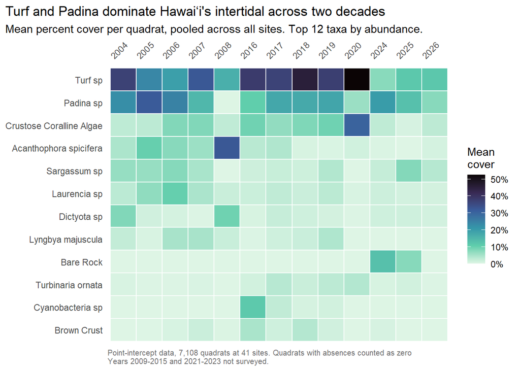

Figure 1: Twelve most abundant taxa, as mean percent cover per quadrat, pooled across every site in each year.

```r
raw <- read_csv(here("Outputs", "clean_master_sheet_percent_cover.csv"),
                show_col_types = FALSE)

# The below below columns together identify ONE quadrat observation
# Verified against the data: these give 7,108 units, every one summing to exactly 100%

quad_keys <- c("date", "site_key", "transect_id", "quadrat_id", "position")

master <- read_csv(here("Outputs", "clean_master_sheet_percent_cover.csv"),
                   show_col_types = FALSE) |>
  mutate(
    date = if (inherits(date, "Date")) date
           else as_date(parse_date_time(date, orders = c("mdy", "ymd"))),
    year = year(date)
  )

stopifnot(!any(is.na(master$year)))

# Rank taxa by total cover across the whole dataset. Summing raw percent_cover
# Absent rows contribute nothing to a sum, so the ranking is unaffected. It is only MEANS that need the zeros made explicit.

top_taxa <- master |>
  group_by(taxon_key) |>
  summarise(total = sum(percent_cover, na.rm = TRUE), .groups = "drop") |>
  slice_max(total, n = 12) |>
  pull(taxon_key)

taxon_year <- master |>
  filter(taxon_key %in% top_taxa) |>
  select(all_of(quad_keys), year, taxon_key, percent_cover) |>
  # Complete within the filtered set - absences become zeros
  # 23,356 rows over 7,108 quadrats is ~3.3 taxa per quadrat out of 207.
  # Without it, mean(percent_cover) = "mean cover WHEN PRESENT",
  # For patchy species is a completely different result
  # nesting() keeps only the quadrat x year combinations that really exist,
  # rather than crossing every column with every other
  complete(nesting(!!!syms(c(quad_keys, "year"))), taxon_key,
           fill = list(percent_cover = 0)) |>
  group_by(year, taxon_key) |>
  summarise(
    mean_cover = mean(percent_cover),
    n_quadrats = n(),
    .groups = "drop"
  ) |>
  # Order taxa by overall abundance so the axis isn't alphabetical
  # Averages each taxon's yearly means to get one sort value per taxon
  mutate(taxon_key = fct_reorder(taxon_key, mean_cover, .fun = mean))

cover_by_taxa_plot <- ggplot(taxon_year, aes(x = factor(year), y = taxon_key, fill = mean_cover)) +
  geom_tile(colour = "white", linewidth = 0.4) +
  # Sequential single hue: lightness rises monotonically with cover, so the
  # reader can tell which end means "more"
  scale_fill_viridis_c(option = "mako", direction = -1,
                       labels = scales::label_number(suffix = "%"),
                       name = "Mean\ncover") +
  scale_x_discrete(position = "top") +
  labs(
    title = "Turf and Padina dominate Hawaiʻi's intertidal across two decades",
    subtitle = "Mean percent cover per quadrat, pooled across all sites. Top 12 taxa by abundance.",
    x = NULL, y = NULL,
    caption = "Point-intercept data, 7,108 quadrats at 41 sites. Quadrats with absences counted as zero\nYears 2009-2015 and 2021-2023 not surveyed."
  ) +
  theme_minimal(base_size = 11) +
  theme(
    panel.grid = element_blank(), # gridlines add nothing behind tiles
    axis.text.x = element_text(angle = 45, hjust = 1),
    plot.title.position = "plot",
    plot.caption = element_text(hjust = 0, colour = "grey45", size = 7.5)
  )

cover_by_taxa_plot
```

### Grouping and Plotting Functions

1. `group_summary()` takes the master sheet and a group name and returns one row per taxon per year. It does three things in a fixed order: identify the most abundant taxa within that group, complete the taxon-by-quadrat grid so absences become zeros, then average. The order matters more than it looks.
2. `group_heatmap()` takes the same arguments and returns a ggplot. Keeping it separate from `group_summary()` means the summarized numbers can be inspected, exported or tested without drawing anything, and the same summary feeds both the static figure and the interactive one.
3. `make_matrix()` exists because plotly will not accept long data for a heat map; it needs a matrix of values with vectors for the row and column labels. `pivot_wider()` names columns in order of first appearance rather than numerically, which would silently produce a chart with its years out of sequence.
4. `to_colorscale()` is a three-line adapter converting an R palette into plotly’s [position, color] format, so the interactive figure uses the same `mako` palette as the static ones.

```r
# case_when() evals top to bottom, stops at the first TRUE
# ORDER IS THE LOGIC here
# Every branch below sits where it does for a reason

draft_groups <- master |>
  distinct(taxon_key) |>
  mutate(functional_group = case_when(

    # Turf first, as its own category - it alone is 30.6% of all cover
    # Kept separated so that algal composition is clearer
    str_detect(taxon_key, regex("\\bturf\\b", ignore_case = TRUE)) ~ "Turf",

    # \\bsand\\b so it cannot match inside "Cellana sandwicensis"
    str_detect(taxon_key, regex("bare rock|^rock$|\\bsand\\b|rubble|pebble|limestone|^hole$|basalt|sediment", ignore_case = TRUE)) ~ "Substrate",

    str_detect(taxon_key, regex("cyanobacteria|lyngbya|symploca", ignore_case = TRUE)) ~ "Cyanobacteria",

    # Crustose coralline algae -> Algae. Must sit ABOVE the coral
    # Otherwise "Coralline" gets caught by "coral"
    str_detect(taxon_key, regex("crustose coralline", ignore_case = TRUE)) ~ "Algae",

    # Same reasoning "Articallate Corraline" might be caught in coral
    str_detect(taxon_key, regex("articulated coralline|^jania|galaxaura|halimeda|bornetella|neomeris|liagora|dichotomaria", ignore_case = TRUE)) ~ "Calcified algae",

    str_detect(taxon_key, regex("coral|porites|montipora|pocillopora", ignore_case = TRUE)) ~ "Coral",

    str_detect(taxon_key, regex("echinometra|urchin|colobocentrotus|cucumber|actinopyga|holothuria|sea star", ignore_case = TRUE)) ~ "Echinoderm",

    # cellana, limpet and opihi live here - they are gastropods
    str_detect(taxon_key, regex("snail|nerita|littorar|littorina|siphonaria|dendropoma|isognomon|thylacodes|morula|brachidontes|haminoea|serpulorbis|mussel|cellana|limpet|opihi", ignore_case = TRUE)) ~ "Mollusc",

    str_detect(taxon_key, regex("barnacle|crab|grapsus|polychaete|anthopleura|anemone|hydroid|pennaria|sponge", ignore_case = TRUE)) ~ "Other invertebrate",

    # \\bcrust\\b with boundaries, so "tenuicrustatus" not caught
    str_detect(taxon_key, regex("unknown|\\bcrust\\b", ignore_case = TRUE)) ~ "Unresolved",

    # Catch-all. Most of the 207 taxa are algae
    # The majority case and goes last by design
    TRUE ~ "Algae"
  ))

count(draft_groups, functional_group, sort = TRUE)
```

```
# A tibble: 10 × 2
   functional_group       n
   <chr>              <int>
 1 Algae                124
 2 Mollusc               20
 3 Echinoderm            14
 4 Calcified algae       11
 5 Coral                  8
 6 Other invertebrate     8
 7 Substrate              8
 8 Unresolved             8
 9 Cyanobacteria          5
10 Turf                   1
```

```r
# Export WITH total abundance, so review effort goes to the taxa that
# actually move the figures rather than down the alphabet
draft_groups |>
  left_join(master |> group_by(taxon_key) |>
              summarise(total = sum(percent_cover, na.rm = TRUE)), by = "taxon_key") |>
  arrange(functional_group, desc(total)) |>
  write_csv(here("Outputs", "functional_groups_to_review.csv"))
```

### Exploring by Functional Group

- Grouping to functional level is more robust, because the classification only has to be right about the kind of organism, not the species
  - Figure 2 tests the grouping and plotting function for the `Coral` classification. Not shown in final code, but each grouping was tested to verify correct classifications and visualizations.
- Figure 3 lets the reader select a functional group and see its most abundant taxa across the survey years
  - Each group is drawn as its own layer and the dropdown switches between them, so the figure works in a static HTML document with no server behind it
- Substrate is excluded because it was only recorded from 2024 onward and cannot share an axis with groups spanning the full period
- Turf is excluded because it is a single taxon and would render as one row.
- The `Unresolved` entries such as `Unknown Red` and `Brown Crust` is retained in the underlying data but not presented as a result, since it describes the limits of field identification rather than the community.

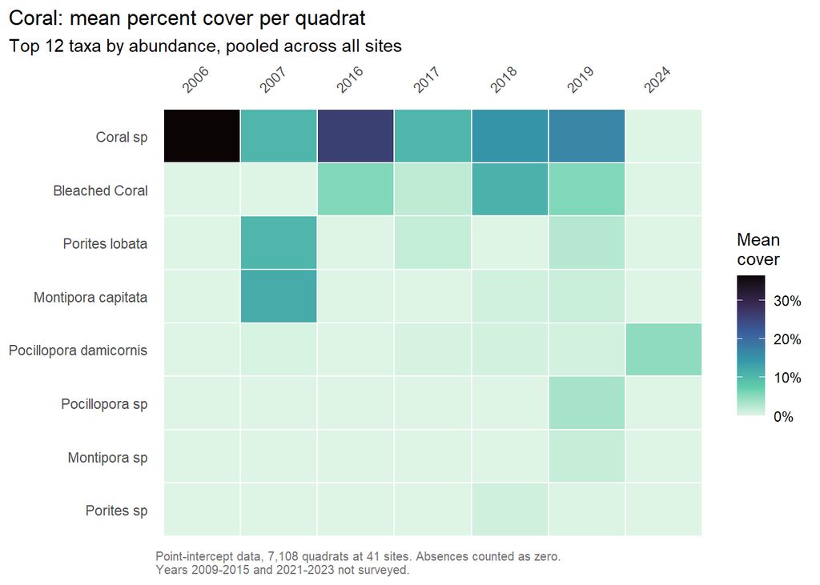

```r
fg_lookup <- draft_groups # swap for read_csv(...) once signed off

master_fg <- master |> left_join(fg_lookup, by = "taxon_key")

# group-filtered summary downstream.
stopifnot(!any(is.na(master_fg$functional_group)))

# Substrate, Turf and Unresolved are excluded from the dropdown
# See notes at the foot of this file for why each one is out
groups <- c("Algae", "Mollusc", "Calcified algae", "Echinoderm",
            "Coral", "Cyanobacteria", "Other invertebrate")


# Summarize one functional group to taxon x year
group_summary <- function(data, group, n_taxa = 12) {
  d <- data |> filter(functional_group == group)

  # Top n taxa within this group, by total cover
  keep <- d |>
    group_by(taxon_key) |>
    summarise(total = sum(percent_cover, na.rm = TRUE), .groups = "drop") |>
    slice_max(total, n = n_taxa) |>
    pull(taxon_key)

  d |>
    filter(taxon_key %in% keep) |>
    select(all_of(quad_keys), year, taxon_key, percent_cover) |>
    # Completion happens AFTER filtering, so that:
    # 1) Zeros only needed for selected taxa
    # 2) Grid stays small enough
    complete(nesting(!!!syms(c(quad_keys, "year"))), taxon_key,
             fill = list(percent_cover = 0)) |>
    group_by(year, taxon_key) |>
    summarise(mean_cover = mean(percent_cover),
              n_quadrats = n(), .groups = "drop") |>
    mutate(taxon_key = fct_reorder(taxon_key, mean_cover, .fun = mean))
}


# Plot one group to test functional groups,
group_heatmap <- function(data, group, n_taxa = 12) {
  d <- group_summary(data, group, n_taxa)

  ggplot(d, aes(x = factor(year), y = taxon_key, fill = mean_cover)) +
    geom_tile(colour = "white", linewidth = 0.4) +
    scale_fill_viridis_c(option = "mako", direction = -1,
                         labels = scales::label_number(suffix = "%"),
                         name = "Mean\ncover") +
    scale_x_discrete(position = "top") +
    labs(
      title = paste0(group, ": mean percent cover per quadrat"),
      subtitle = paste("Top", n_taxa, "taxa by abundance, pooled across all sites"),
      x = NULL, y = NULL,
      caption = "Point-intercept data, 7,108 quadrats at 41 sites. Absences counted as zero.\nYears 2009-2015 and 2021-2023 not surveyed."
    ) +
    theme_minimal(base_size = 11) +
    theme(panel.grid = element_blank(),
          axis.text.x = element_text(angle = 45, hjust = 1),
          plot.title.position = "plot",
          plot.caption = element_text(hjust = 0, colour = "grey45", size = 7.5))
}

# Test it out using one of the functional group classifiers
group_heatmap(master_fg, "Coral")
```

```r
# Plotly cannot filter a heatmap from long data.
# Built ONE TRACE PER GROUP up front, show only the first.
# The buttons flip which trace is visible.
# Nothing is recomputed on click, so it works as static HTML.

# Build one z-matrix per group: rows = taxa, columns = years.
# Row and column order are set explicitly, because pivot_wider() orders
# columns by first appearance, not numerically.

make_matrix <- function(g) {
  d <- group_summary(master_fg, g)

  # Sorted separately because pivot_wider() names columns by order
  # Here, I sort numerically by year
  yrs <- sort(unique(d$year))

  w <- d |>
    pivot_wider(id_cols = taxon_key, names_from = year, values_from = mean_cover) |>
    # taxn_key is a factor order by abundance
    # plotly draws y bottom-up
    # ascending order puts most abundant on top
    arrange(taxon_key) |>
    # factor order = ascending abundance
    select(taxon_key, all_of(as.character(yrs)))

  list(
    y = as.character(w$taxon_key), # plotly uses character ≠ factor
    x = as.character(yrs),
    z = as.matrix(w[, -1]) # drop the label column
  )
}

# set_names() lets the trace and button loop address groups by name
# as opposed to index, so they are not dropped
mats <- set_names(map(groups, make_matrix), groups)

# Make coloscale in plotly [position, color]
to_colorscale <- function(cols) {
  cols <- substr(cols, 1, 7)
  # strip alpha - plotly rejects 8-digit hex
  n <- length(cols)
  map(seq_len(n), \(i) list((i - 1) / (n - 1), cols[i]))
}

# rev() because mako runs dark-to-light
# we want dark to represent more cover as opposed to less
mako_scale <- to_colorscale(rev(viridisLite::mako(9)))

# One trace per group; only the first is visible at load
p <- plot_ly()
for (g in groups) {
  m <- mats[[g]]
  p <- add_trace(p,
    z = m$z, x = m$x, y = m$y,
    type = "heatmap",
    colorscale = mako_scale,
    visible = (g == groups[1]),     # only first group drawn at load
    xgap = 1, ygap = 1,             # the white tile borders
    colorbar = list(
      title        = list(text = "Mean<br>cover (%)", side = "top"),
    # <br> no \n: potly title are HTML, so "\n" prints literally
      x            = 1.02,          # just right of the plot area
      xanchor      = "left",
      y            = 1,
      yanchor      = "top",   # top of the bar at the top of the plot
                              # won't wonky with fewer taxa
      len          = 0.75,          # 75% of plot height
      lenmode      = "fraction",
      thickness    = 14,            # pixels wide
      outlinewidth = 0,
      ticksuffix   = "%"
    ),
# <extra></extra> suppreses plotly's default "trace 0" box
    hovertemplate = "%{y}<br>%{x}<br>%{z:.2f}%<extra></extra>"
  )
}

# One button per group. `groups == g` evaluates to a TRUE/FALSE vector of exactly the right length - one entry per trace, in trace order
# Each button flips the visibility vector and swaps the title
buttons <- map(groups, function(g) {
  list(
    method = "update",
    label  = g,
    args   = list(
      list(visible = groups == g),
      list(title = list(text = paste0(g, ": mean percent cover per quadrat")))
    )
  )
})

cover_dropdown <- p |>
  layout(
    title = list(text = paste0(groups[1], ": mean percent cover per quadrat"),
                 x = 0, xanchor = "left"),
    xaxis = list(side = "top", title = "", type = "category"),
    yaxis = list(title = "", type = "category"),
    height = 560, # fixed, so switching groups doesn't resize
# Bottom margin holds  menu; top  only needs title + year labels
# Margins are load-bearing: plotly doesn't expand for long labels,
# Bars or menus:
    # Anything outside the plot area needs margin
    # If not, plot gets squeezed to make room.
# l: taxon, r: the colorbar, t: title + year labels, b: the menu
# FIXED: r was 30, too narrow for the colorbar added at x = 1.02
    margin = list(l = 180, r = 100, t = 90, b = 140),
    updatemenus = list(list(
      type        = "dropdown",
      direction   = "up",         # opens UPWARD, overlaying the plot
      xref        = "paper",      # pos against figure, not the data
      yref        = "paper",
      x           = 1.2,
      xanchor     = "right",      # right edge of figure
      y           = -0.05,
      yanchor     = "bottom",     # menu hangs below the plot area
      bgcolor     = "white",
      bordercolor = "grey70",
      borderwidth = 1,
      font        = list(size = 9),
      showactive  = TRUE,
      buttons     = buttons
    )),
      text = "Functional group:", showarrow = FALSE,
      xref = "paper", yref = "paper",
      x = 0.78, xanchor = "right", y = -0.15, yanchor = "top",
      font = list(size = 11, color = "grey40")
    )
```

[interactive chart not shown]

Figure 3: Mean percent cover per quadrat by taxon and survey year, for the most abundanttaxa within functional group. Use the dropdown to switch groups. Color scales independently within each functional group, so shading is comparable within a selection but not between selections.

## Plotting: Changes in Community Structure with NMDS, line, and point plots

### Loading libraries:

```r
library(tidyverse)   # dplyr, ggplot2, tidyr, purrr, lubridate, forcats
library(vegan)       # NMDS, Bray-Curtis
library(ggrepel)     # non-overlapping labels
library(scales)
library(broom)       # tidy model output
library(here)
```

#### *Setting theme:*

```r
# sets one look for every plot in the document: minimal theme, no minor gridlines, left-aligned bold titles
theme_set(
  theme_minimal(base_size = 13) +
    theme(panel.grid.minor = element_blank(),
          plot.title.position = "plot",
          plot.title = element_text(face = "bold"))
)
```

### Loading data

```r
# reads the cleaned master sheet (one row = one taxon's count in one quadrat on one date)
dat <- read_csv(here("Outputs", "final_clean_master_sheet.csv"))
```

### Data wrangling

```r
# adds a year column, drops rows with no taxon or a missing/zero count (zero-count rows aren't observations)
dat <- dat %>%
  mutate(year = year(date)) %>%
  filter(!is.na(taxon_key), !is.na(count), count > 0)
```

Had issues with duplicate entries from missing metadata (missing quadrat/transect IDs) causing duplicate entries for the same observations; fixing with the code below.

Identifying duplicated observations (2024-2026)

```r
# ------------------------------------------------------------
# DEFINE WHAT MAKES TWO ROWS "THE SAME OBSERVATION"
#     Everything about *what was seen where and when*; deliberately
#     excludes the metadata columns that differ between the copies.
# ------------------------------------------------------------
# ID the columns that identify one observation. Two rows that match on
# all of these are treated as copies of the same observation.
# (NA counts as a match, so the all-NA quadrat_id in 2024+ doesn't block dedupe.)
key_cols <- c("date", "site_key", "transect_id", "quadrat_id",
              "position", "taxon_raw", "count")
```

```r
# ------------------------------------------------------------
# DIAGNOSE: how many observations appear more than once, by year?
#     Expect ~0% in most years and ~100% in 2025-2026 if your hunch is right.
# ------------------------------------------------------------
dup_check <- dat %>%
  mutate(year = year(date)) %>%
  count(year, across(all_of(key_cols)), name = "n_copies")

dup_check %>%
  group_by(year) %>%
  summarise(rows           = sum(n_copies),
            unique_obs     = n(),
            pct_duplicated = round(100 * mean(n_copies > 1), 1),
            max_copies     = max(n_copies)) %>%
  print(n = Inf)

# Eyeball one duplicated observation: which columns differ between copies?
example <- dup_check %>% filter(n_copies > 1) %>% slice(1) %>% select(all_of(key_cols))
dat %>%
  semi_join(example, by = key_cols) %>%
  select(all_of(key_cols), everything()) %>%
  glimpse()

# Also check the copies agree on the count. If this returns rows, the
# "duplicates" disagree on abundance and need a human decision:
dat %>%
  mutate(year = year(date)) %>%
  filter(year %in% 2024:2025) %>%
  group_by(across(all_of(setdiff(key_cols, "count")))) %>%
  filter(n_distinct(count) > 1) %>%
  ungroup() %>%
  nrow()
```

Fixing duplicated entries:

```r
# ------------------------------------------------------------
# FIX
#     Only touch the affected years: in earlier years, a taxon listed twice
#     in a quadrat could be a legitimate repeat and shouldn't be collapsed.
# ------------------------------------------------------------
dup_years <- 2024:2026  # the years that had duplicated entries; only these years get deduped

# Keep whichever copy has the most metadata filled in
# Counts non-missing cells per row, sorts so the fullest copy comes first, then keeps the first row for each unique observation
dedupe_keep_fullest <- function(df) {
  df %>%
    mutate(n_filled = rowSums(!is.na(across(everything())))) %>%
    arrange(desc(n_filled)) %>%
    distinct(across(all_of(key_cols)), .keep_all = TRUE) %>%
    select(-n_filled)
}

# Leaves 2004-2020 untouched, dedupes 2024-2026, and stacks them back together in date/site/transect order
dat_clean <- bind_rows(
  dat %>% filter(!year(date) %in% dup_years),
  dat %>% filter( year(date) %in% dup_years) %>% dedupe_keep_fullest()
) %>%
  arrange(date, site_key, transect_id, quadrat_id)
```

```r
# ------------------------------------------------------------
# VERIFY: rerun the diagnostic on dat_clean. pct_duplicated should be
#     ~0 for 2024-2025 and row counts for those years should roughly halve.
# ------------------------------------------------------------
dat_clean %>%
  mutate(year = year(date)) %>%
  count(year, across(all_of(key_cols)), name = "n_copies") %>%
  group_by(year) %>%
  summarise(rows = sum(n_copies), pct_duplicated = round(100 * mean(n_copies > 1), 1)) %>%
  print(n = Inf)

nrow(dat); nrow(dat_clean)
```

Setting cleaned data as main dataframe to use from here:

```r
# From here on, `dat` is the deduplicated data
dat <- dat_clean
```

Now, building counts within quadrats:

```r
# Building the working table for everything below. For each site, date and
# taxon, adds up the counts within each quadrat.

# A quadrat is identified by site + date + transect + POSITION (not quadrat_id,
# which is blank in 2024-2026). This collapses any remaining repeated entries
# of the same taxon in the same quadrat into a single count.

quad_taxa <- dat %>%
  mutate(quad_uid = paste(site_key, date, transect_id, position, sep = "|")) %>%
  group_by(site_key, date, year, quad_uid, taxon_key) %>%
  summarise(count = sum(count), .groups = "drop")
```

Calculating sampling effort to standardize plots by # of quadrats sampled

```r
# Sampling effort: number of quadrats per site-year (used to turn counts
# into densities, so years with more sampling don't look "more abundant")

# `effort` is used below to convert counts into densities (individuals
# per quadrat) for the NMDS and the winners/losers trends.

effort <- quad_taxa %>%
  group_by(site_key, year) %>%
  summarise(n_quadrats = n_distinct(quad_uid),
            .groups = "drop")
```

### NMDS plot by island

Calculating NMDS trajectories

```r
# ------------------------------------------------------------
# COMMUNITY COMPOSITION: NMDS TRAJECTORIES
# ------------------------------------------------------------
# Builds the site x taxon table of densities (one row per site-year, one
# column per taxon, zeros filled in). Used by the NMDS and the winners/losers trends.

site_year_dens <- quad_taxa %>%
  group_by(site_key, year, taxon_key) %>%
  summarise(n = sum(count), .groups = "drop") %>%
  left_join(effort, by = c("site_key", "year")) %>%
  mutate(density = n / n_quadrats) %>%
  select(site_key, year, taxon_key, density) %>%
  pivot_wider(names_from = taxon_key, values_from = density, values_fill = 0) %>%
  arrange(site_key, year)

# Splits the table into labels (`meta`) and the numbers-only matrix
# (`comm`). The square root reduces the influence of a few very abundant taxa.
meta <- site_year_dens %>% select(site_key, year)
comm <- site_year_dens %>% select(-site_key, -year) %>% as.matrix() %>% sqrt()

# Runs the NMDS: Bray-Curtis dissimilarity between site-years, squashed
# into 2 dimensions. Then attaches each site-year's coordinates to its labels.
set.seed(1)   # makes code reproducible so that plot doesn't come out different each rendering
nmds <- metaMDS(comm, distance = "bray", k = 2, trymax = 50, trace = 0)
nmds_df <- bind_cols(meta, as.data.frame(scores(nmds, display = "sites")))
```

Assigning each site to an island using latitude/longitudes:

```r
# ------------------------------------------------------------
#  ASSIGN EACH SITE TO AN ISLAND
#    No island column in the data, so use each site's lat/long and pick the
#    nearest island center. CHECK THE RESULT below, then patch by hand.
# ------------------------------------------------------------
# Approximate center point of each island (latitude, longitude)
islands <- tribble(
  ~island,   ~ilat,  ~ilon,
  "Kauaʻi",    22.05, -159.55,
  "Oʻahu",     21.47, -157.98,
  "Molokaʻi",  21.14, -157.02,
  "Lānaʻi",    20.83, -156.92,
  "Maui",      20.80, -156.33,
  "Hawaiʻi",   19.58, -155.50
)

# Given a coordinate, returns the name of the closest island center
# (NA if the site has no coordinates)
nearest_island <- function(lat, lon) {
  if (is.na(lat) || is.na(lon)) return(NA_character_)
  islands$island[which.min((islands$ilat - lat)^2 + (islands$ilon - lon)^2)]
}

# One row per site with its average coordinates, then its assigned island
site_island <- dat %>%
  group_by(site_key) %>%
  summarise(latitude  = mean(latitude,  na.rm = TRUE),
            longitude = mean(longitude, na.rm = TRUE),
            .groups = "drop") %>%
  mutate(island = map2_chr(latitude, longitude, nearest_island))

# Sanity checks: sites per island, and any sites without coordinates
site_island %>% count(island)
site_island %>% arrange(island, site_key) %>% print(n = Inf)

# Manual fix for Mamala Bay, which didn't have lat/long coordinates from dataframe
site_island$island[site_island$site_key == "Mamala Bay"] <- "Oʻahu"

# One color per island.
# Names must match  island names exactly (including the okina and kahakō) or that island loses its color.
island_cols <- c("Kauaʻi" = "#1b9e77", "Oʻahu" = "#d95f02", "Molokaʻi" = "#7570b3",
                 "Lānaʻi" = "#e7298a", "Maui" = "#66a61e", "Hawaiʻi" = "#e6ab02")
```

Making NMDS plot (site-year), colored by island

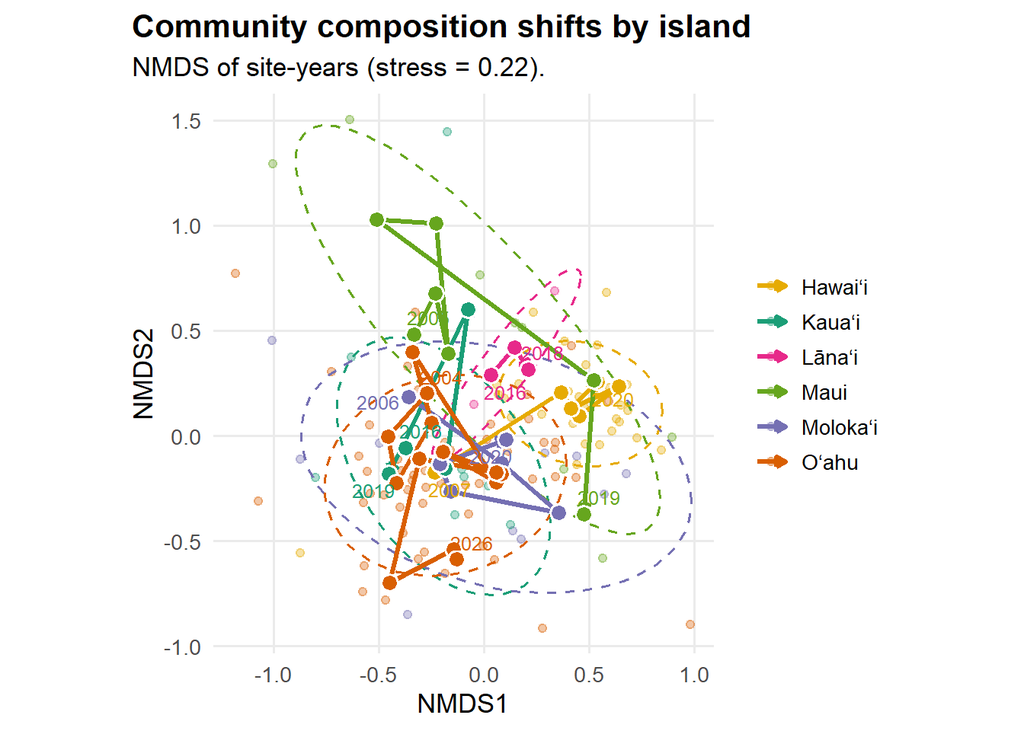

Figure 4: NMDS visualizing community composition shifts by island across time. Bold lines = island centroid through time. First and last year of data collection printed for each island.

```r
# ------------------------------------------------------------
# SITE-YEAR NMDS, COLORED BY ISLAND
#    Faint points = individual site-years. Ellipses = island spread.
#    Bold path = island centroid through time (first and last year labeled).
# ------------------------------------------------------------
# Attaches each site-year's island; drops any site with no island
nmds_isl <- nmds_df %>%
  left_join(select(site_island, site_key, island), by = "site_key") %>%
  filter(!is.na(island))

# Average NMDS position of each island in each year (the bold path).
centroids <- nmds_isl %>%
  group_by(island, year) %>%
  summarise(NMDS1 = mean(NMDS1), NMDS2 = mean(NMDS2), .groups = "drop") %>%
  arrange(island, year)

# Only the first and last year of each island get a text label
centroid_labels <- centroids %>%
  group_by(island) %>%
  filter(year %in% c(min(year), max(year)))

# The plot, layer by layer:
#   geom_point (faint)      each site-year, colored by island
#   stat_ellipse (dashed)   80% ellipse showing each island's spread
#   geom_path (bold arrow)  island centroid moving through time
#   geom_point (large)      centroid for each year
#   geom_text_repel         year labels at start and end of each path
#   coord_equal             keeps both NMDS axes on the same scale
p_nmds_island <- ggplot(nmds_isl, aes(NMDS1, NMDS2, color = island)) +
  geom_point(alpha = 0.35, size = 1.8) +
  stat_ellipse(level = 0.8, linewidth = 0.6, linetype = "dashed") +
  geom_path(data = centroids, linewidth = 1.1,
            arrow = arrow(length = unit(0.18, "cm"), type = "closed")) +
  geom_point(data = centroids, aes(fill = island), shape = 21,
             color = "white", size = 3.5, stroke = 0.8) +
  geom_text_repel(data = centroid_labels, aes(label = year),
                  size = 3.3, show.legend = FALSE, seed = 1) +
  scale_color_manual(values = island_cols, name = NULL) +
  scale_fill_manual(values = island_cols, guide = "none") +
  coord_equal() +
  labs(title = "Community composition shifts by island",
       subtitle = sprintf("NMDS of site-years (stress = %.2f).",
                          nmds$stress))
p_nmds_island
```

### Taxon diversity across time (pooled sites):

```r
# ------------------------------------------------------------
# DIVERSITY THROUGH TIME
#    Metrics computed per quadrat, then averaged. This keeps them
#    comparable across years even when effort differs.
# ------------------------------------------------------------
# One row per quadrat with its diversity metrics.
# The final plots only use `richness` (number of distinct taxa in the quadrat).

div_quad <- quad_taxa %>%
  group_by(site_key, date, year, quad_uid) %>%
  summarise(richness = n_distinct(taxon_key),
            .groups = "drop")
```

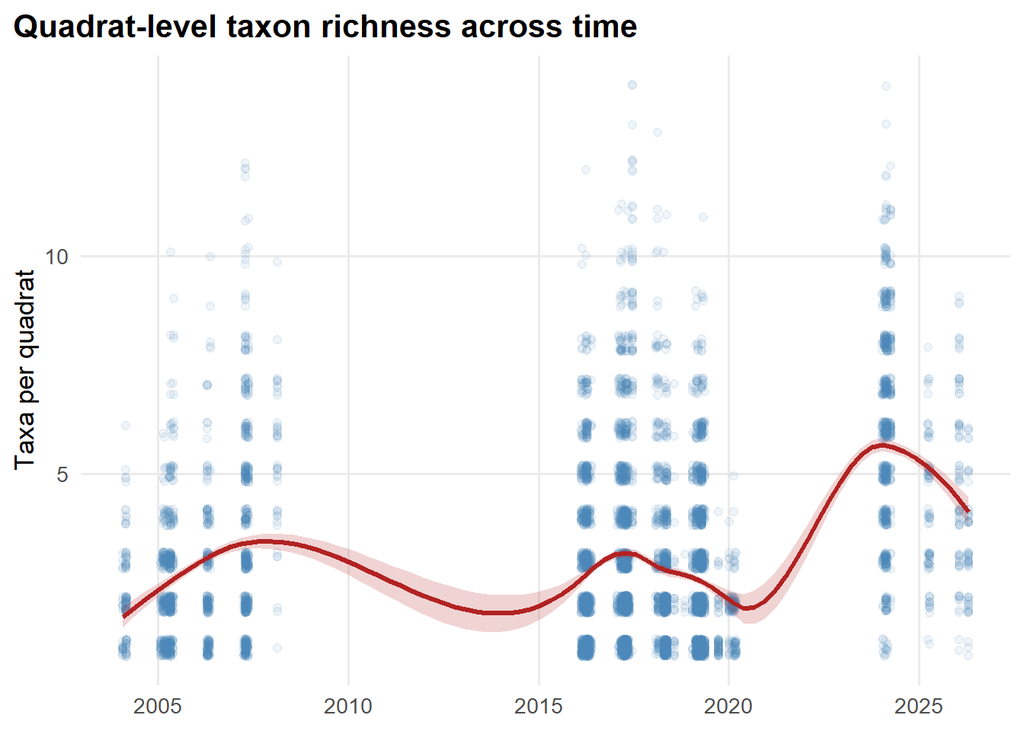

Figure 5: Quadrat-level taxon richness (number of taxa per quadrat) across time. Every dot is one quadrat, the red line is a LOESS smooth with uncertainty band. The smooth is drawn straight across the survey gaps (2009-2015, 2021-2023), so the line there is an interpolation, not data.

```r
# Pooled richness plot: every dot is one quadrat (jittered vertically so
# overlapping points are visible); the red line is a LOESS smooth of richness
# over time with its uncertainty band.

# Note: The smooth is drawn straight across the survey gaps
# (2009-2015, 2021-2023), so the line there is an interpolation, not data.

p_div_pooled <- div_quad %>%
  ggplot(aes(date, richness)) +
  geom_jitter(alpha = 0.08, width = 0, height = 0.2, color = "steelblue") +
  geom_smooth(method = "loess", span = 0.6, color = "firebrick", fill = "firebrick", alpha = 0.2) +
  labs(title = "Quadrat-level taxon richness across time", x = NULL, y = "Taxa per quadrat")
p_div_pooled
```

### Taxon richness over time, by island

```r
# ============================================================
# Community richness over time, by island
# ============================================================

# Adds each quadrat's island; drops quadrats from sites with no island
rich_isl <- div_quad %>%
  left_join(select(site_island, site_key, island), by = "site_key") %>%
  filter(!is.na(island))
```

```r
# ------------------------------------------------------------
# MEAN RICHNESS PER QUADRAT, ONE LINE PER ISLAND
#    Per-quadrat richness is effort-standardized, so years with more
#    sampling don't automatically look richer.
# ------------------------------------------------------------
# Mean richness per quadrat for each island-year, with standard error
# (SE is NA where an island-year has only one quadrat) and the number of
# quadrats behind each mean (used for point size)
island_year_rich <- rich_isl %>%
  group_by(island, year) %>%
  summarise(mean = mean(richness),
            se   = sd(richness) / sqrt(n()),
            n_quadrats = n(),
            .groups = "drop")
```

Plotting only through 2020, where we have data across all islands:

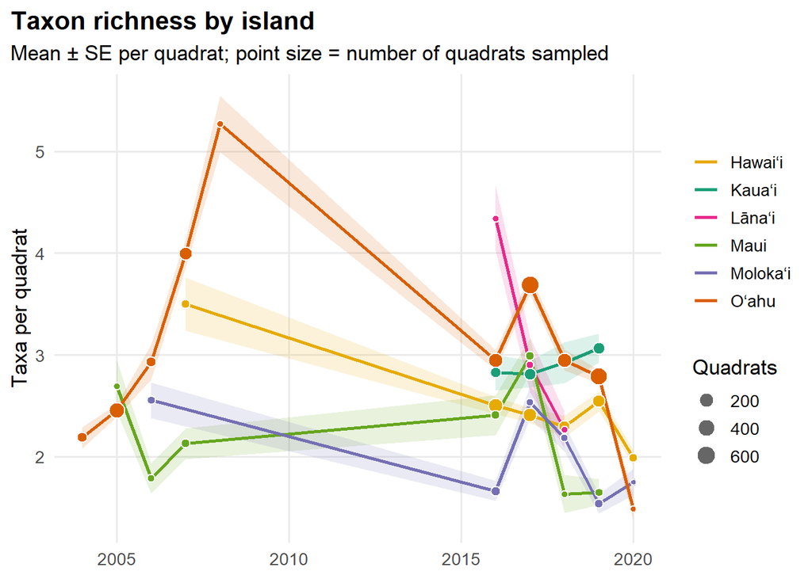

Figure 6: Quadrat-level taxon richness (number of taxa per quadrat) across time, by island. Mean ± SE is plotted, with point size representing the number of quadrats sampled. Data through 2020 is plotted.

```r
# Plotting function; `max_year` cuts off the x-axis (Inf = show all years).
#   geom_ribbon   mean +/- SE band
#   geom_line     island mean through time (connects across survey gaps)
#   geom_point    one dot per island-year, sized by number of quadrats
#   guides(size)  makes the size legend keys show up in grey
plot_rich_island <- function(max_year = Inf) {
  island_year_rich %>%
    filter(year <= max_year) %>%
    ggplot(aes(year, mean, color = island, fill = island)) +
    geom_ribbon(aes(ymin = mean - se, ymax = mean + se), alpha = 0.15, color = NA) +
    geom_line(linewidth = 1) +
    geom_point(aes(size = n_quadrats), shape = 21, color = "white", stroke = 0.6) +
    scale_color_manual(values = island_cols, name = NULL) +
    scale_fill_manual(values = island_cols, guide = "none") +
    scale_size_continuous(range = c(1.5, 5), name = "Quadrats") +
    guides(size = guide_legend(override.aes = list(fill = "grey40", color = "grey40")))+
    scale_x_continuous(breaks = pretty_breaks()) +
    labs(title = "Taxon richness by island",
         subtitle = "Mean \u00b1 SE per quadrat; point size = number of quadrats sampled",
         x = NULL, y = "Taxa per quadrat")
}

# Draws the plot using only data through 2020, where we have data for all islands
p_rich_island_2020 <- plot_rich_island(max_year = 2020)
p_rich_island_2020
```

Plotting through 2026, to visualize all data:

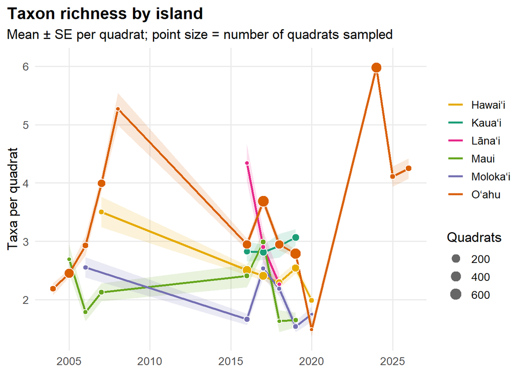

Figure 7: Quadrat-level taxon richness (number of taxa per quadrat) across time, by island. Mean ± SE is plotted, with point size representing the number of quadrats sampled.

```r
# Including 2024-2026 data; calling plot_rich_island() with no argument.
plot_rich_island()
```

### Visualizing trends of “winners and losers” per-taxon trend over time

Calculating trends using model: log1p(density) ~ year + site (site-years incl. zeros).

- fits a linear model of *log(1 + density)* on year
- taking log of data avoids slope skewing from big counts
- *+ site* term corrects for site differences

```r
# Reshapes the site-year x taxon table back into long format: one row per
# site, year and taxon, with zeros included for absences
dens_long <- site_year_dens %>%
  pivot_longer(-c(site_key, year), names_to = "taxon_key", values_to = "density")

# For each taxon (keeping only those present in at least 8 site-years),
# fits a linear model of log(1 + density) on year, with site as a factor so
# each site is compared with itself over time. Keeps just the `year` slope
# (change per year) and its 95% confidence interval.
trends <- dens_long %>%
  group_by(taxon_key) %>%
  filter(sum(density > 0) >= 8) %>%               # need enough presences
  group_modify(~ tidy(lm(log1p(density) ~ year + site_key, data = .x), conf.int = TRUE) %>%
                 filter(term == "year")) %>%
  ungroup()
```

Plotting trends:

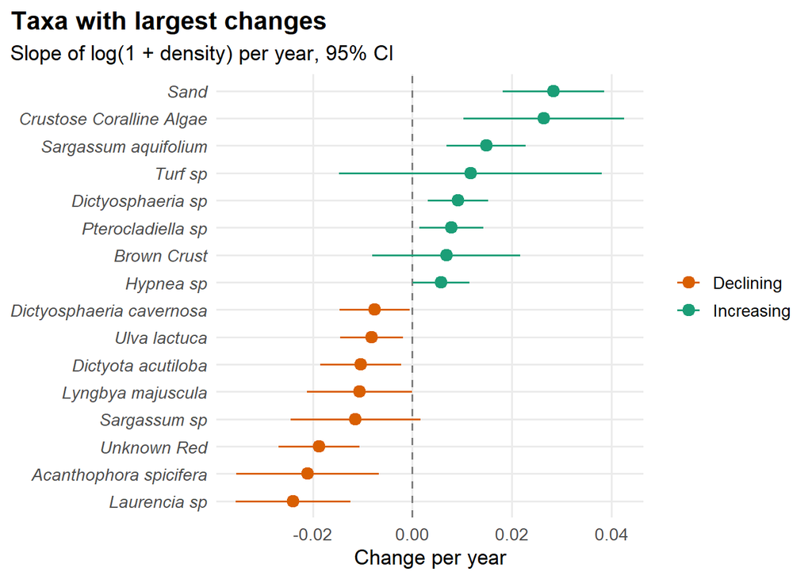

Figure 8: ‘Winners’ and ‘losers’ of intertidal taxa, visualizing change in individual taxa across time, calculated using a linear model of log(1 + density). Displays the 8 most positive and 8 most negative slopes, ± 95% CI.

```r
# Takes the 8 most positive and 8 most negative slopes, labels each as
# Increasing or Declining, and plots slope +/- 95% CI, ordered by slope.
# `distinct()` prevents duplicate rows if there are fewer than 16 taxa.
# A dashed line at 0 marks "no change"; intervals crossing it aren't clearly
# different from no trend.

p_trends <- bind_rows(slice_max(trends, estimate, n = 8),
                      slice_min(trends, estimate, n = 8)) %>%
  distinct() %>%
  mutate(direction = if_else(estimate > 0, "Increasing", "Declining")) %>%
  ggplot(aes(estimate, fct_reorder(taxon_key, estimate), color = direction)) +
  geom_vline(xintercept = 0, linetype = "dashed", color = "grey50") +
  geom_pointrange(aes(xmin = conf.low, xmax = conf.high)) +
  scale_color_manual(values = c(Increasing = "#1b9e77", Declining = "#d95f02"), name = NULL) +
  labs(title = "Taxa with largest changes", subtitle = "Slope of log(1 + density) per year, 95% CI",
       x = "Change per year", y = NULL) +
  theme(axis.text.y = element_text(face = "italic"))
p_trends
```

## Analysis: Calculating a PERMANOVA table to accompany the NMDS plot created in the previous step

### Loading libraries

```r
library(tidyverse)
library(here)
library(praise)
```

### Loading and filtering data

```r
tidal_raw_data <- read_csv(here("Outputs", "clean_master_sheet_percent_cover.csv"))
view(tidal_raw_data)

tidal_data_clean <- tidal_raw_data |>
  mutate(year = year(as.Date(date)),                                               # Create a column for year only
         transect_id = ifelse(is.na(transect_id), "T0",paste0("T",transect_id)),   # Clean up NAs in transect/quadrat IDs if present
         quadrat_id = ifelse(is.na(quadrat_id), "Q0", paste0("Q", quadrat_id)),
         sample_id = paste(site_key,date,transect_id,quadrat_id,sep="_")) |>         # create a new column with a sample ID for each line for the PERMANOVA
  select(sample_id,year,site_key,taxon_key,percent_cover) |>                       # Select only the columns we want to keep for analysis
  filter(!is.na(taxon_key),!is.na(percent_cover))                                  # Filter out the columns with NA values
view(tidal_data_clean)
```

### Performing a PERMANOVA analysis utilizing AI scripted code guidance

```r
## Load libraries
library(vegan)

## Pivot dataframe to wide format
tidal_data_wide <- tidal_data_clean |>
  group_by(sample_id,year,site_key,taxon_key) |>
  summarise(percent_cover = mean(percent_cover,na.rm=TRUE),.groups="drop") |>  # Summarize data by average percent cover
  pivot_wider(names_from = taxon_key,
              values_from = percent_cover,
              values_fill=0)                                                   # Fill absent taxa with 0% cover
view(tidal_data_wide)

## Separate metadata and species matrix with row names for vegan package
spp_matrix <- tidal_data_wide |>            # Create a matrix of species data with sample_id as row names
  select(-year,-site_key) |>
  column_to_rownames(var = "sample_id") |>
  as.matrix()
valid_samples <- rowSums(spp_matrix) >0     # Filter out any samples that have 0 total cover across all taxa
spp_matrix <- spp_matrix[valid_samples, ]
meta <- tidal_data_wide |>                  # Create metadata dataframe aligned exactly to spp_matrix
  select(sample_id,year,site_key) |>
  filter(sample_id %in% rownames(spp_matrix)) |>
  column_to_rownames(var="sample_id") |>
  mutate(year = as.factor(year))

## Use Bray-Curtis dissimilarity, which is standard for community percent cover data
dist_matrix <- vegdist(spp_matrix,method="bray")     # Calculate the Bray-Curtis distance matrix
permanova_result <- adonis2(dist_matrix~year,
                            data = meta,
                            permutations = 99,
                            by = "terms")

print(permanova_result)
```

```
Permutation test for adonis under reduced model
Terms added sequentially (first to last)
Permutation: free
Number of permutations: 99

adonis2(formula = dist_matrix ~ year, data = meta, permutations = 99, by = "terms")
           Df SumOfSqs      R2      F Pr(>F)
year       12    96.22 0.04097 22.373   0.01 **
Residual 6285  2252.44 0.95903
Total    6297  2348.65 1.00000
---
Signif. codes:  0 '***' 0.001 '**' 0.01 '*' 0.05 '.' 0.1 ' ' 1
```

All pau with data cleaning and plotting!  
Please see the ReadMe associated with this Quarto document for a discussion on data trends.